# EJP-Soil INSE01 data analyse

Sam Lambrechts

Silke De Backer

2024-03-27

# 1 Inlezen data

```r
path_naar_bestand <- file.path(
    ejp_folder,
    "Bodem_biodiversiteit",
    "03_resultaten",
    "phyloseq",
    "inse01",
    "physeq_Inse01.Rdata"
  )

load(path_naar_bestand)

path_naar_bestand2 <- file.path(
    ejp_folder,
    "Bodem_biodiversiteit",
    "03_resultaten",
    "phyloseq",
    "inse01",
    "physeq_Inse01_Arthropoda.Rdata"
  )

load(path_naar_bestand2)

path_naar_bestand3 <- file.path(
    ejp_folder,
    "Bodem_biodiversiteit",
    "03_resultaten",
    "phyloseq",
    "inse01",
    "physeq_Inse01_subset_species.Rdata"
  )

load(path_naar_bestand3)
```

Het bestand dat wordt ingelezen is physeq_Inse01.Rdata en physeq_Inse01_Arthropoda.Rdata en physeq_Inse01_subset_species.Rdata.

# 2 Preprocessing stappen

verwijder Gontrode, strooiselstalen, en replicaten

```r
physeq <- physeq_insecta_subset.species
physeq_full <- physeq_Inse01_Arthropoda # includes Collembola and unknown Arthropoda OTUs
physeq_Inse01 <- physeq_Inse01 # also includes Annelida

physeq <- subset_samples_no_zero(physeq, Locatie != "Gontrode")
physeq_full <- subset_samples_no_zero(physeq_full, Locatie != "Gontrode")
physeq_Inse01 <- subset_samples_no_zero(physeq_Inse01, Locatie != "Gontrode")

physeq <- subset_samples_no_zero(physeq, Protocol2 != "strooisel")
physeq_full <- subset_samples_no_zero(physeq_full, Protocol2 != "strooisel")
physeq_Inse01 <- subset_samples_no_zero(physeq_Inse01, Protocol2 != "strooisel")

physeq_known_species <- subset_taxa(physeq, !grepl("_otu", tax_table(physeq)[, "species"]))
physeq_known_genera <- subset_taxa(physeq, !grepl("_otu", tax_table(physeq)[, "genus"]))
physeq_known_order <- subset_taxa(physeq, !grepl("_otu", tax_table(physeq)[, "order"]))
physeq_known_family <- subset_taxa(physeq, !grepl("_otu", tax_table(physeq)[, "family"]))
```

physeq is een subset van de data, en bevat namelijk enkel de volgende 5 klassen: Insecta, Arachnida, Chilopoda, Diplura, en Malacostraca. physeq full is alles van Arthropoda. Physeq inse01 zijn alle OTUs die gerecupereerd zijn met de inse01 primerset, inclusief de ongewenste bijvangst zoals Annelida. physeq full is dus een subset van physeq inse01, en physeq is dus een verdere subset van physeq full.

```r
sample_sums(physeq_Inse01)
```

```
##    Molenbeek_0_10    Herentals_0_10   Diepenbeek_0_10     Burdinne_0_10
##            158205            239177            294732             21550
##  Cerfontaine_0_10       Deurne_0_10      Genappe_0_10      Bredene_0_10
##            199026            177684             99993            163019
##    Sombreffe_0_10      Seneffe_0_10        Marke_0_10   Molenbeek_10_30
##            255420            262161            397633            285371
##   Herentals_10_30  Diepenbeek_10_30    Burdinne_10_30 Cerfontaine_10_30
##            242084            378565            178155            157312
##      Deurne_10_30     Genappe_10_30     Bredene_10_30   Sombreffe_10_30
##            257248             58000            114514            216605
##     Seneffe_10_30       Marke_10_30    Burdinne_Lucas       Marke_Lucas
##            216460            146206             29474            165569
##  Diepenbeek_Lucas     Genappe_Lucas     Bredene_Lucas Cerfontaine_Lucas
##            408064             65860            221604             48979
##   Sombreffe_Lucas     Seneffe_Lucas   Molenbeek_Lucas
##             56042            195364             74419
```

```r
sample_sums(physeq_full)
```

```
##    Molenbeek_0_10    Herentals_0_10   Diepenbeek_0_10     Burdinne_0_10
##             26629             78104            220258              1553
##  Cerfontaine_0_10       Deurne_0_10      Genappe_0_10      Bredene_0_10
##             54888             20491              8080              9150
##    Sombreffe_0_10      Seneffe_0_10        Marke_0_10   Molenbeek_10_30
##             29263            166379             12057             42316
##   Herentals_10_30  Diepenbeek_10_30    Burdinne_10_30 Cerfontaine_10_30
##            138782            226756             50047            108826
##      Deurne_10_30     Genappe_10_30     Bredene_10_30   Sombreffe_10_30
##             97983             21825             52242             99285
##     Seneffe_10_30       Marke_10_30    Burdinne_Lucas       Marke_Lucas
##             73343             13365              7556             31369
##  Diepenbeek_Lucas     Genappe_Lucas     Bredene_Lucas Cerfontaine_Lucas
##            206096               992            135297             40125
##   Sombreffe_Lucas     Seneffe_Lucas   Molenbeek_Lucas
##              3779             14249             17348
```

```r
sample_sums(physeq)
```

```
##    Molenbeek_0_10    Herentals_0_10   Diepenbeek_0_10     Burdinne_0_10
##              1193             25437             80116               255
##  Cerfontaine_0_10       Deurne_0_10      Genappe_0_10      Bredene_0_10
##             36355             14787              6853               679
##    Sombreffe_0_10      Seneffe_0_10        Marke_0_10   Molenbeek_10_30
##             22628            162859              2874              3464
##   Herentals_10_30  Diepenbeek_10_30    Burdinne_10_30 Cerfontaine_10_30
##             15476            133836              1956            102431
##      Deurne_10_30     Genappe_10_30     Bredene_10_30   Sombreffe_10_30
##              5368             16525              4004             30641
##     Seneffe_10_30       Marke_10_30    Burdinne_Lucas       Marke_Lucas
##              4818               923               210              3773
##  Diepenbeek_Lucas     Genappe_Lucas     Bredene_Lucas Cerfontaine_Lucas
##              1292               842              7006             35318
##   Sombreffe_Lucas     Seneffe_Lucas   Molenbeek_Lucas
##               163              4517              1229
```

## 2.1 Filter en selectie stappen

Filter taxongroep:

```r
physeq <- subset_taxa(physeq, phylum != "Human")
physeq_full <- subset_taxa(physeq_full, phylum != "Human")
physeq_Inse01 <- subset_taxa(physeq_Inse01, phylum != "Human")

physeq <- subset_taxa(physeq, phylum != "Unknown")
physeq_full <- subset_taxa(physeq_full, phylum != "Unknown")
physeq_Inse01 <- subset_taxa(physeq_Inse01, phylum != "Unknown")
```

rarefied

```r
sample_sums <- sample_sums(physeq)


write.csv(sample_sums, file = "Inse01_subset_sample_sums.csv")

sample_sums <- sample_sums(physeq_full)


write.csv(sample_sums, file = "Inse01_arthropoda_full_sample_sums.csv")


sample_sums <- sample_sums(physeq_Inse01)

write.csv(sample_sums, file = "Inse01_full_incl_Annelida_sample_sums.csv")

getwd()
```

```
## [1] "C:/Bioinformatica/R/EJP-Soil/EJP-Soil"
```

```r
physeq_full_rarefied <- rarefy_even_depth(physeq_full, sample.size = 12057)
```

```
## You set `rngseed` to FALSE. Make sure you've set & recorded
##  the random seed of your session for reproducibility.
## See `?set.seed`
```

```
## ...
```

```
## 6 samples removedbecause they contained fewer reads than `sample.size`.
```

```
## Up to first five removed samples are:
```

```
## Burdinne_0_10Genappe_0_10Bredene_0_10Burdinne_LucasGenappe_Lucas
```

```
## ...
```

```
## 12OTUs were removed because they are no longer
## present in any sample after random subsampling
```

```
## ...
```

## 2.2 Conversie voor gebruik in andere packages

Voorbereidende stap: functies om een `phyloseq` object te converteren naar een `vegan matrix` of een `tidytacos` object.

```r
psotu2veg <- function(physeq) {
  otu <- phyloseq::otu_table(physeq)
  if (phyloseq::taxa_are_rows(otu)) {
    otu <- t(otu)
  }
  return(as(otu, "matrix"))
}

veganobject <- psotu2veg(physeq)
```

```r
psotu2veg <- function(physeq_full) {
  otu <- phyloseq::otu_table(physeq_full)
  if (phyloseq::taxa_are_rows(otu)) {
    otu <- t(otu)
  }
  return(as(otu, "matrix"))
}

veganobject_physeq_full <- psotu2veg(physeq_full)
```

```r
psotu2veg <- function(physeq_Inse01) {
  otu <- phyloseq::otu_table(physeq_Inse01)
  if (phyloseq::taxa_are_rows(otu)) {
    otu <- t(otu)
  }
  return(as(otu, "matrix"))
}

veganobject_physeq_inse01 <- psotu2veg(physeq_Inse01)
```

```r
tidy_physeq_inse01 <- tidytacos::from_phyloseq(physeq_Inse01)
tidy_physeq <- tidytacos::from_phyloseq(physeq_full)
tidy_physeq_insecta <- tidytacos::from_phyloseq(physeq)
tidy_physeq_rarefied <- tidytacos::from_phyloseq(physeq_full_rarefied)
tidy_physeq_known_species <- tidytacos::from_phyloseq(physeq_known_species)
tidy_physeq_known_genera <- tidytacos::from_phyloseq(physeq_known_genera)
tidy_physeq_known_family <- tidytacos::from_phyloseq(physeq_known_family)
tidy_physeq_known_order <- tidytacos::from_phyloseq(physeq_known_order)
tidy_physeq_inse01 <- tidy_physeq_inse01 %>%
  remove_empty_samples() %>%
  tidytacos::set_rank_names(
    rank_names = c("phylum", "class", "order", "family", "genus", "species")
  ) %>%
  tidytacos::add_alpha() %>%
  tidytacos::add_total_count()


tidy_physeq <- tidy_physeq %>%
  remove_empty_samples() %>%
  tidytacos::set_rank_names(
    rank_names = c("phylum", "class", "order", "family", "genus", "species")
  ) %>%
  tidytacos::add_alpha() %>%
  tidytacos::add_total_count()

tidy_physeq_insecta <- tidy_physeq_insecta %>%
  remove_empty_samples() %>%
  tidytacos::set_rank_names(
    rank_names = c("phylum", "class", "order", "family", "genus", "species")
  ) %>%
  tidytacos::add_alpha() %>%
  tidytacos::add_total_count()

tidy_physeq_rarefied <- tidy_physeq_rarefied %>%
  remove_empty_samples() %>%
  tidytacos::set_rank_names(
    rank_names = c("phylum", "class", "order", "family", "genus", "species")
  ) %>%
  tidytacos::add_alpha() %>%
  tidytacos::add_total_count()

tidy_physeq_known_species <- tidy_physeq_known_species %>%
  remove_empty_samples() %>%
  tidytacos::set_rank_names(
    rank_names = c("phylum", "class", "order", "family", "genus", "species")
  ) %>%
  tidytacos::add_alpha() %>%
  tidytacos::add_total_count()

tidy_physeq_known_genera <- tidy_physeq_known_genera %>%
  remove_empty_samples() %>%
  tidytacos::set_rank_names(
    rank_names = c("phylum", "class", "order", "family", "genus", "species")
  ) %>%
  tidytacos::add_alpha() %>%
  tidytacos::add_total_count()

tidy_physeq_known_family <- tidy_physeq_known_family %>%
  remove_empty_samples() %>%
  tidytacos::set_rank_names(
    rank_names = c("phylum", "class", "order", "family", "genus", "species")
  ) %>%
  tidytacos::add_alpha() %>%
  tidytacos::add_total_count()

tidy_physeq_known_order <- tidy_physeq_known_order %>%
  remove_empty_samples() %>%
  tidytacos::set_rank_names(
    rank_names = c("phylum", "class", "order", "family", "genus", "species")
  ) %>%
  tidytacos::add_alpha() %>%
  tidytacos::add_total_count()
```

# 3 Verkennende analyses

```r
physeq_Inse01
```

```
## phyloseq-class experiment-level object
## otu_table()   OTU Table:         [ 470 taxa and 31 samples ]
## sample_data() Sample Data:       [ 31 samples by 24 sample variables ]
## tax_table()   Taxonomy Table:    [ 470 taxa by 6 taxonomic ranks ]
```

```r
physeq_full
```

```
## phyloseq-class experiment-level object
## otu_table()   OTU Table:         [ 293 taxa and 31 samples ]
## sample_data() Sample Data:       [ 31 samples by 24 sample variables ]
## tax_table()   Taxonomy Table:    [ 293 taxa by 6 taxonomic ranks ]
```

```r
physeq_full_rarefied
```

```
## phyloseq-class experiment-level object
## otu_table()   OTU Table:         [ 281 taxa and 25 samples ]
## sample_data() Sample Data:       [ 25 samples by 24 sample variables ]
## tax_table()   Taxonomy Table:    [ 281 taxa by 6 taxonomic ranks ]
```

```r
physeq
```

```
## phyloseq-class experiment-level object
## otu_table()   OTU Table:         [ 107 taxa and 31 samples ]
## sample_data() Sample Data:       [ 31 samples by 24 sample variables ]
## tax_table()   Taxonomy Table:    [ 107 taxa by 6 taxonomic ranks ]
```

## 3.1 Sample data

```r
glimpse(sample_data(physeq) %>% as_tibble())
```

```
## Rows: 31
```

```
## Columns: 24
## $ Naam             <chr> "Molenbeek_0_10", "Herentals_0_10", "Diepenbeek_0_10"…
## $ Locatie          <chr> "Molenbeek", "Herentals", "Diepenbeek", "Burdinne", "…
## $ Protocol         <chr> "INBO", "INBO", "INBO", "INBO", "INBO", "INBO", "INBO…
## $ Protocol2        <chr> "INBO_0_10", "INBO_0_10", "INBO_0_10", "INBO_0_10", "…
## $ Laag             <chr> "0_10", "0_10", "0_10", "0_10", "0_10", "0_10", "0_10…
## $ Bodembedekking   <chr> "Recreatie", "Cultuurgrasland_permanent", "Loofbos", …
## $ Landgebruik      <chr> "Recreatie", "Grasland", "Bos", "Akker", "Grasland", …
## $ EUNIS            <chr> "V2", "R1", "T1", "V1", "R1", "R1", "V1", "V1 ", "V1"…
## $ Vegetatie        <chr> "Engels_raaigras", "Engels_raaigras", "Amerikaanse ei…
## $ Vegetatie2       <chr> "Geen", "Geen", "Amerikaanse_vogelkers", "Geen", "zur…
## $ Vegetatie3       <chr> "Geen", "Geen", "Geen", "Geen", "witte klaver", "Geen…
## $ Vegetatie4       <chr> "Geen", "Geen", "Geen", "Geen", "paarse klaver", "Gee…
## $ Vegetatie5       <chr> "Mono", "Mono", "Mix", "Mono", "Mix", "Mono", "Mono",…
## $ Bewerkt          <chr> "Nee", "Bemest", "Nee", "Nee", "Gekalkt", "Nee", "Nee…
## $ Weer             <chr> "Zonnig", "Bewolkt", "Regen", "Zonnig", "Bewolkt", "B…
## $ Voorafgaand_weer <chr> "Droog", "Geen_neerslag", "Hevige_neerslag", "Hevige_…
## $ Helling          <chr> "Ja", "Nee", "Ja", "Nee", "Ja", "Nee", "Nee", "Nee", …
## $ Bodemverstoring  <chr> "Geen", "Bodemverwonding", "Geen", "Bodemverwonding",…
## $ Grachten         <chr> "Nee", "Nee", "Nee", "Ja", "Nee", "Nee", "Nee", "Nee"…
## $ Oogstresten      <chr> "Nee", "Nee", "Nee", "Ja", "Nee", "Nee", "Ja", "Ja", …
## $ Grind            <chr> "Ja", "Nee", "Ja", "Nee", "Ja", "Nee", "Nee", "Nee", …
## $ Houtskool        <chr> "Nee", "Nee", "Nee", "Nee", "Nee", "Nee", "Ja", "Nee"…
## $ Roest            <chr> "Nee", "Nee", "Nee", "Nee", "Ja", "Nee", "Nee", "Nee"…
## $ Antropogeen_mat  <chr> "Nee", "Ja", "Nee", "Nee", "Nee", "Ja", "Nee", "Nee",…
```

Kijken of sample data in nederlands of engels staat (om namen te weten variabelen voor analyse hieronder)

Check totaal aantal reads (hier de decielen van 0% = minimum tot 100% = maximum):

```r
sample_sums(physeq) %>%
  quantile(probs = seq(0, 1, 0.1))
```

```
##     0%    10%    20%    30%    40%    50%    60%    70%    80%    90%   100%
##    163    679   1193   1956   3773   4818   7006  16525  30641  80116 162859
```

We verkennen ook de verdeling van de samples over de belangrijkste design-variabelen:

```r
tidy_physeq$samples %>%
  count(Protocol2, Landgebruik) %>%
  kable()
```

| Protocol2 | Landgebruik | n |
| --- | --- | --- |
| INBO_0_10 | Akker | 4 |
| INBO_0_10 | Bos | 2 |
| INBO_0_10 | Grasland | 4 |
| INBO_0_10 | Recreatie | 1 |
| INBO_10_30 | Akker | 4 |
| INBO_10_30 | Bos | 2 |
| INBO_10_30 | Grasland | 4 |
| INBO_10_30 | Recreatie | 1 |
| Lucas | Akker | 4 |
| Lucas | Bos | 2 |
| Lucas | Grasland | 2 |
| Lucas | Recreatie | 1 |

Aantal bodemlocaties:

```r
tidy_physeq$samples %>%
  group_by(Landgebruik) %>%
  summarise(n_locaties = n_distinct(Naam)) %>%
  kable()
```

| Landgebruik | n_locaties |
| --- | --- |
| Akker | 12 |
| Bos | 6 |
| Grasland | 10 |
| Recreatie | 3 |

```r
tidy_physeq$samples %>%
  group_by(Protocol2) %>%
  summarise(n_locaties = n_distinct(Naam)) %>%
  kable()
```

| Protocol2 | n_locaties |
| --- | --- |
| INBO_0_10 | 11 |
| INBO_10_30 | 11 |
| Lucas | 9 |

De meeste 0-10 cm en 10-30 cm stalen zijn van dezelfde locatie. Met deze gepaardheid moeten we rekening houden in analyses.

Vergeet niet Deurne en Herentals te verwijderen voor de staalname protocol vergelijkingen

## 3.2 OTU tabel

```r
glimpse(otu_table(physeq) %>% as.data.frame %>% as_tibble())
```

```
## Rows: 107
## Columns: 31
## $ Molenbeek_0_10    <dbl> 0, 0, 0, 0, 0, 192, 0, 0, 0, 0, 0, 0, 0, 0, 0, 0, 0,…
## $ Herentals_0_10    <dbl> 0, 0, 0, 0, 0, 0, 0, 20667, 0, 0, 0, 992, 0, 0, 0, 0…
## $ Diepenbeek_0_10   <dbl> 13172, 3, 0, 25159, 0, 0, 0, 0, 36605, 0, 0, 0, 0, 0…
## $ Burdinne_0_10     <dbl> 0, 0, 0, 0, 0, 0, 0, 0, 0, 0, 0, 0, 0, 0, 0, 0, 0, 4…
## $ Cerfontaine_0_10  <dbl> 0, 0, 15224, 0, 0, 7030, 0, 0, 0, 0, 0, 0, 0, 0, 0, …
## $ Deurne_0_10       <dbl> 0, 0, 0, 0, 0, 54, 0, 12961, 0, 0, 0, 0, 10, 0, 0, 0…
## $ Genappe_0_10      <dbl> 0, 0, 0, 0, 0, 0, 5949, 0, 0, 0, 553, 0, 0, 0, 0, 0,…
## $ Bredene_0_10      <dbl> 0, 0, 0, 0, 0, 0, 0, 0, 0, 0, 0, 0, 0, 0, 0, 0, 0, 8…
## $ Sombreffe_0_10    <dbl> 0, 0, 0, 0, 0, 0, 0, 0, 0, 0, 0, 0, 0, 0, 0, 0, 0, 1…
## $ Seneffe_0_10      <dbl> 0, 0, 0, 0, 158713, 1769, 0, 0, 0, 0, 0, 0, 131, 0, …
## $ Marke_0_10        <dbl> 74, 0, 0, 0, 0, 0, 0, 0, 0, 0, 0, 0, 1, 0, 0, 0, 0, …
## $ Molenbeek_10_30   <dbl> 0, 0, 0, 0, 0, 510, 0, 0, 0, 0, 0, 0, 0, 0, 0, 0, 0,…
## $ Herentals_10_30   <dbl> 0, 0, 0, 0, 0, 0, 0, 211, 0, 0, 0, 14065, 0, 0, 0, 0…
```

[output cut: 18 more lines]

## 3.3 Taxonomie tabel

```r
glimpse(tax_table(physeq) %>% as.data.frame %>% as_tibble())
```

```
## Rows: 107
## Columns: 6
## $ phylum  <chr> "Arthropoda", "Arthropoda", "Arthropoda", "Arthropoda", "Arthr…
## $ class   <chr> "Insecta", "Insecta", "Arachnida", "Insecta", "Insecta", "Inse…
## $ order   <chr> "Coleoptera", "Coleoptera", "Acari", "Coleoptera", "Coleoptera…
## $ family  <chr> "Hydraenidae", "Elateridae", "Acari_otu262", "Tenebrionidae", …
## $ genus   <chr> "Hydraenidae_otu68", "Athous", "Acari_otu262", "Nalassus", "Am…
## $ species <chr> "Hydraenidae_otu68", "Athous_haemorrhoidalis", "Acari_otu262",…
```

```r
species <- as.vector(tax_table(physeq)[, "species"])
species <- species[!grepl("_otu", species)]
species <- gsub("_", " ", species)
source(here::here("source/r/check_presence.R"))
gbif_check <- check_presence(species)
gbif_check %>%
filter(!present) %>%
  kable(caption = "Not present according to GBIF in Western-Europe")
```

Table 3.1: Not present according to GBIF in Western-Europe

| present | scientific_name |
| --- | --- |
| FALSE | Nematopogon swammerdamellus |
| FALSE | Eupteryx gracilirama |

## 3.4 Unieke en gedeelde taxa per staalname protocol per locatie:

#### 3.4.0.1 1. Alle soorten

```r
# Your original phyloseq object (replace with your actual object)
phyloseq_venn <- physeq_full_rarefied

print(phyloseq_venn)
```

```
## phyloseq-class experiment-level object
## otu_table()   OTU Table:         [ 281 taxa and 25 samples ]
## sample_data() Sample Data:       [ 25 samples by 24 sample variables ]
## tax_table()   Taxonomy Table:    [ 281 taxa by 6 taxonomic ranks ]
```

```r
# Extract sample data
sample_data <- as.data.frame(sample_data(phyloseq_venn))

# Extract unique locations and corresponding protocols
locations <- unique(sample_data$Locatie)
protocols <- lapply(locations, function(loc) unique(sample_data$Protocol[sample_data$Locatie == loc]))

# Initialize vector to store samples to be removed
samples_to_remove <- character(0)

# Identify samples to be removed based on conditions
for (i in seq_along(locations)) {
  if (length(protocols[[i]]) == 1 && protocols[[i]] == "INBO") {
    samples_to_remove <- c(samples_to_remove, rownames(sample_data[sample_data$Locatie == locations[i], ]))
  }
}

# Remove duplicates
samples_to_remove <- unique(samples_to_remove)

# Which samples need to be removed?
samples_to_remove
```

```
## [1] "Herentals_0_10"  "Herentals_10_30" "Deurne_0_10"     "Deurne_10_30"
## [5] "Sombreffe_0_10"  "Sombreffe_10_30" "Burdinne_10_30"  "Genappe_10_30"
```

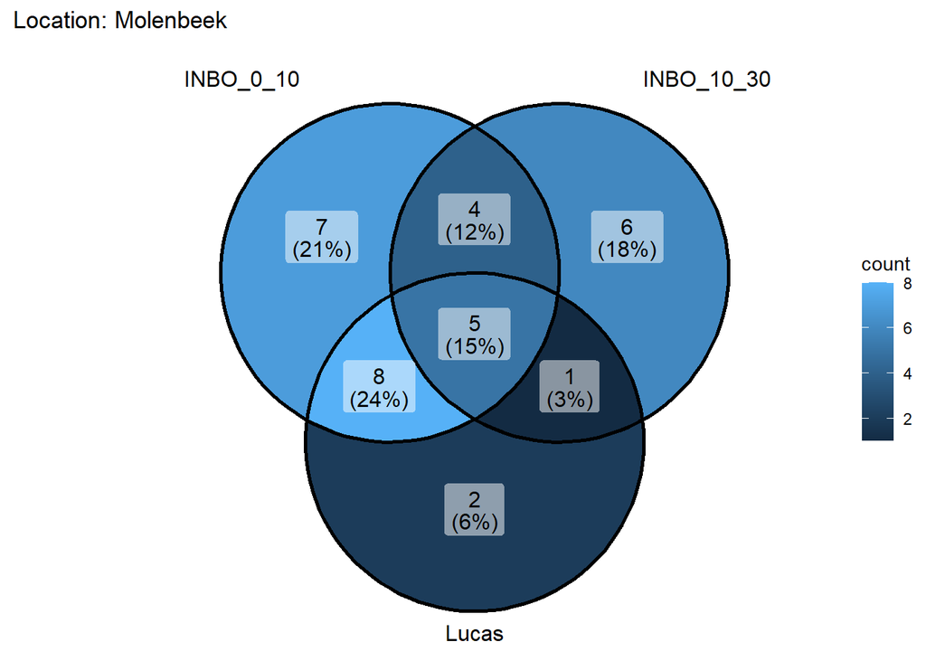

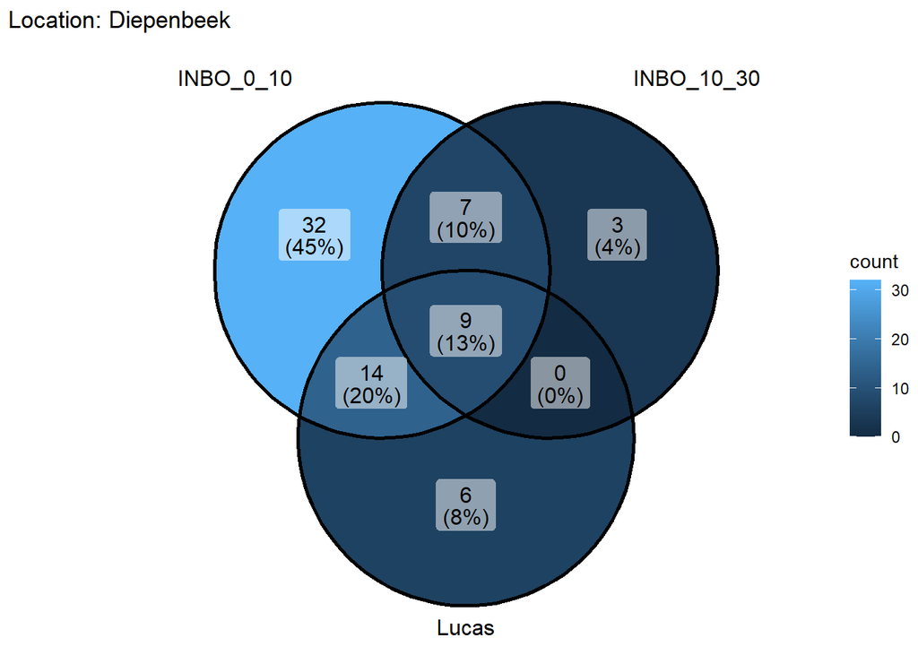

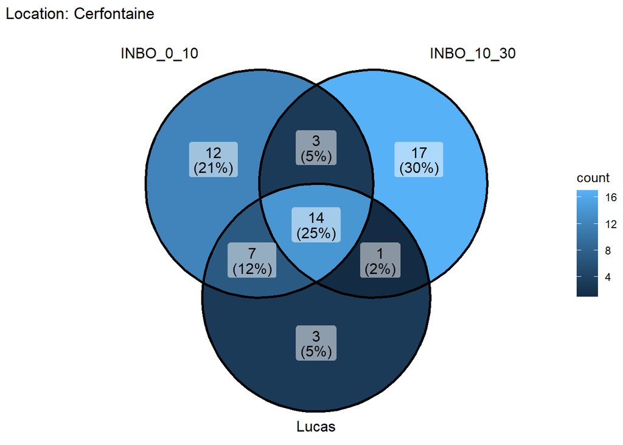

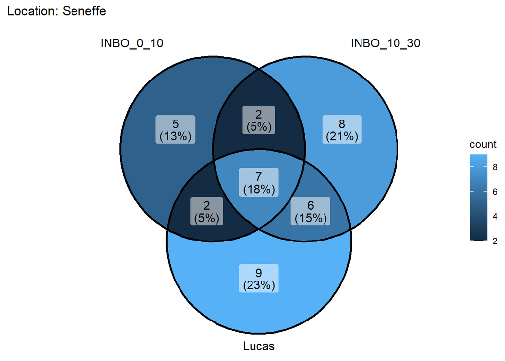

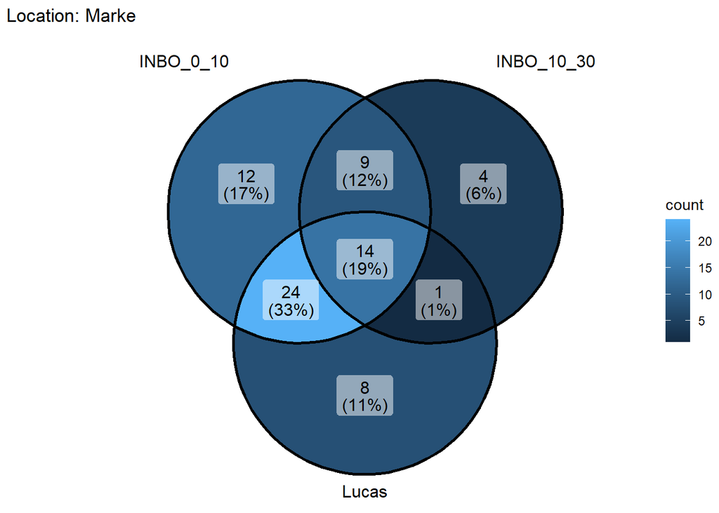

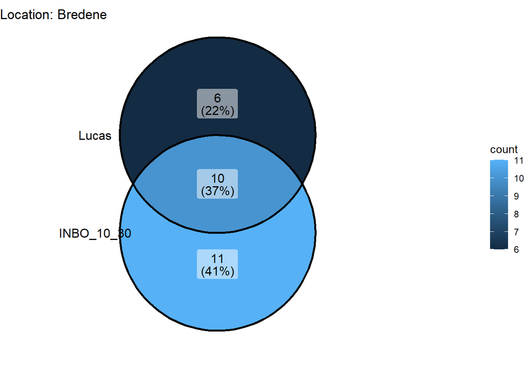

```r
# Remove samples

# Sombreffe, Burdinne, en Genappe vallen af tijdens de aanmaak van het rarefied phyloseq object, omdat die minder reads hadden dan de gekozen threshold. Zetten we deze threshold lager, of indien we werken met de non-rarefied versie, dan krijgen we voor alle 9 locaties Venn diagrammen. We kunnen hier met spelen en deze verschillende opties eens testen en Venn diagrammen vergelijken.

phyloseq_venn_filtered <- subset_samples_no_zero(phyloseq_venn, !(Naam %in% samples_to_remove))



# Make venn_diagram per
# Per locatie
phyloseq_venn_filtered_location <- phyloseq_venn_filtered

# List of unique locations
locations <- unique(sample_data(phyloseq_venn_filtered_location)$Locatie)

# Create an empty list to store the subsetted phyloseq objects
phyloseq_list <- list()

# Loop through each location
for (loc in locations) {
  # Subset the phyloseq object for the current location
  phyloseq_sub <- subset_samples_no_zero(phyloseq_venn_filtered_location, Locatie == loc)

  # Assign the subsetted phyloseq object to a variable with the location name
  assign(paste0("phyloseq_", loc), phyloseq_sub)

  # Store the subsetted phyloseq object in the list
  phyloseq_list[[loc]] <- phyloseq_sub
}


# List to store plots
plots_venn_locations <- list()


# Loop over each location
for (location in locations) {
  # Create tidy_physeq object
  tidy_physeq_venn <- tidytacos::from_phyloseq(get(paste0("phyloseq_", location)))

  # Generate plot with specified size and add title
  plot <- tidy_physeq_venn %>%
    tidytacos::tacoplot_venn(Protocol2) +
    ggtitle(paste("Location:", location)) +
    expand_limits(x = c(-8, 10), y = c(-5, 5))  # Adjust expansion here

  # Store plot in the list
  plots_venn_locations[[location]] <- plot
}
# Now you can access each plot from the list and display it
for (location in locations) {
  print(plots_venn_locations[[location]])
}
```

#### 3.4.0.2 2. Enkel gekende soorten

```r
# Subset only known species
physeq_known_species_venn <- subset_taxa(phyloseq_venn, !grepl("_otu", tax_table(phyloseq_venn)[, "species"]))

print(physeq_known_species_venn)
```

```
## phyloseq-class experiment-level object
## otu_table()   OTU Table:         [ 191 taxa and 25 samples ]
## sample_data() Sample Data:       [ 25 samples by 24 sample variables ]
## tax_table()   Taxonomy Table:    [ 191 taxa by 6 taxonomic ranks ]
```

```r
# Extract sample data
sample_data <- as.data.frame(sample_data(physeq_known_species_venn))

# Extract unique locations and corresponding protocols
locations <- unique(sample_data$Locatie)
protocols <- lapply(locations, function(loc) unique(sample_data$Protocol[sample_data$Locatie == loc]))

# Initialize vector to store samples to be removed
samples_to_remove <- character(0)

# Identify samples to be removed based on conditions
for (i in seq_along(locations)) {
  if (length(protocols[[i]]) == 1 && protocols[[i]] == "INBO") {
    samples_to_remove <- c(samples_to_remove, rownames(sample_data[sample_data$Locatie == locations[i], ]))
  }
}

# Remove duplicates
samples_to_remove <- unique(samples_to_remove)

# Which samples need to be removed?
samples_to_remove
```

```
## [1] "Herentals_0_10"  "Herentals_10_30" "Deurne_0_10"     "Deurne_10_30"
## [5] "Sombreffe_0_10"  "Sombreffe_10_30" "Burdinne_10_30"  "Genappe_10_30"
```

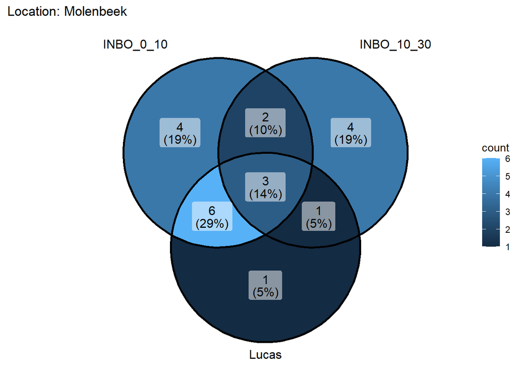

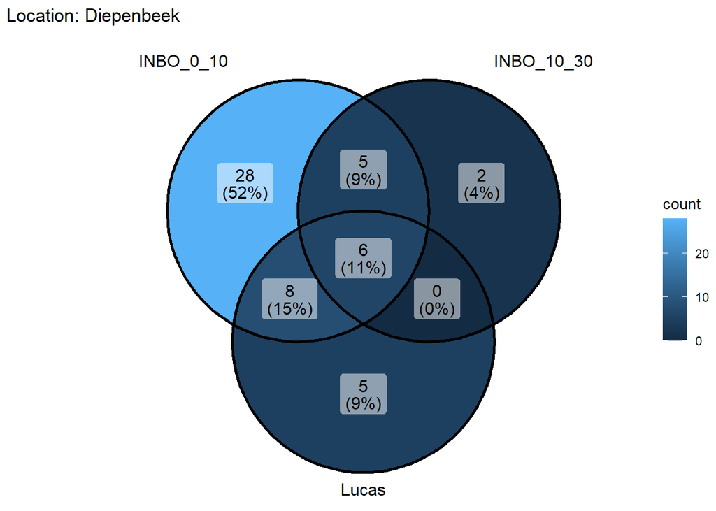

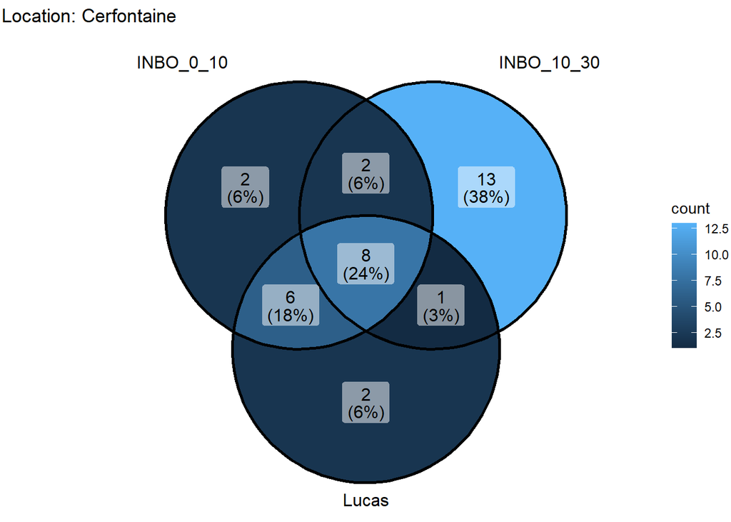

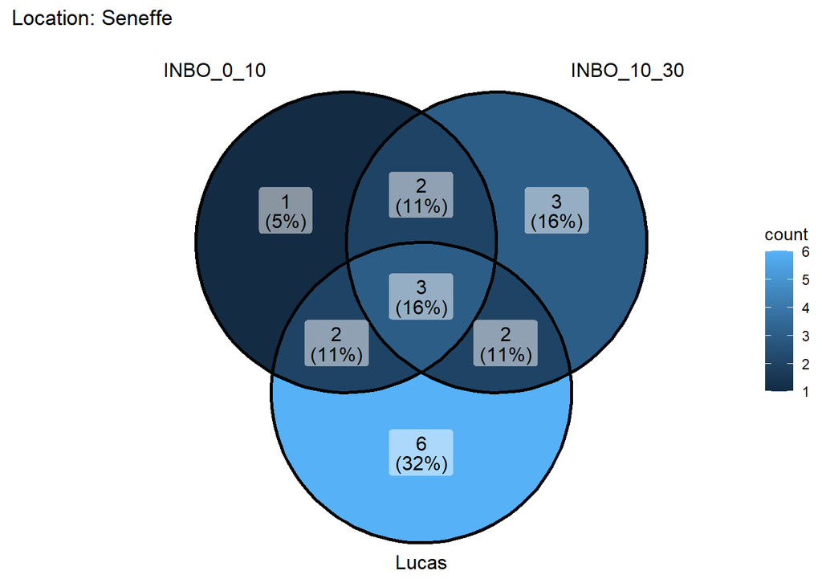

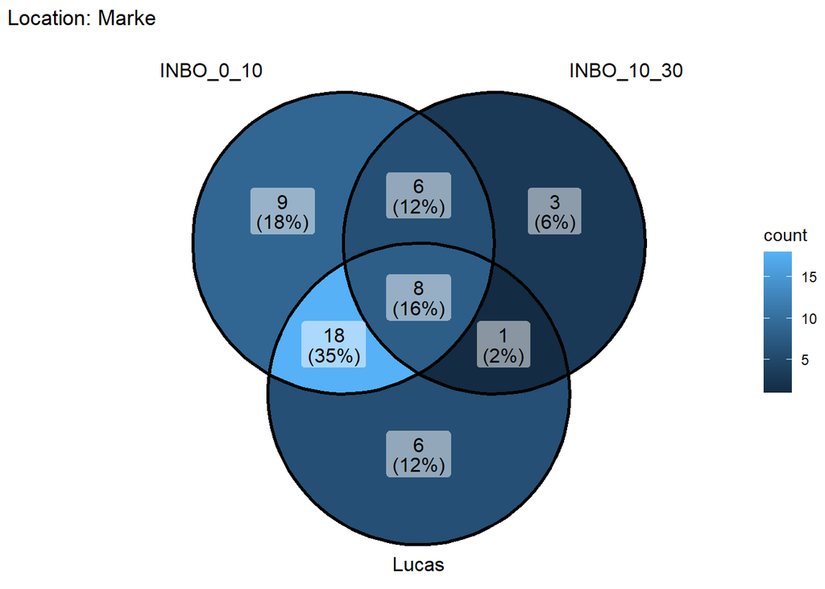

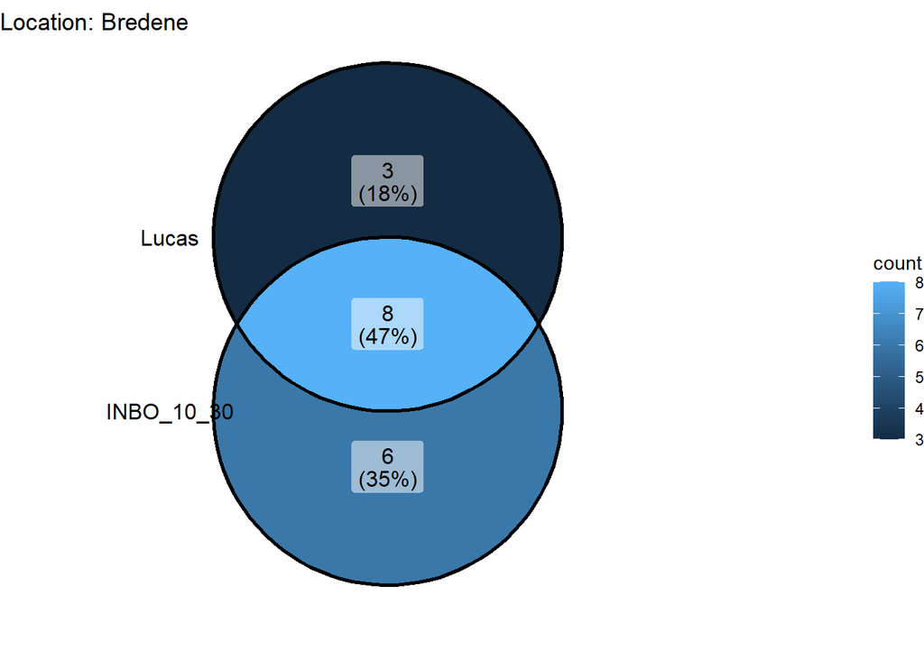

```r
# Remove samples

# Sombreffe, Burdinne, en Genappe vallen af tijdens de aanmaak van het rarefied phyloseq object, omdat die minder reads hadden dan de gekozen threshold. Zetten we deze threshold lager, of indien we werken met de non-rarefied versie, dan krijgen we voor alle 9 locaties Venn diagrammen. We kunnen hier met spelen en deze verschillende opties eens testen en Venn diagrammen vergelijken.

phyloseq_venn_filtered <- subset_samples_no_zero(physeq_known_species_venn, !(Naam %in% samples_to_remove))



# Make venn_diagram per
# Per locatie
phyloseq_venn_filtered_location <- phyloseq_venn_filtered

# List of unique locations
locations <- unique(sample_data(phyloseq_venn_filtered_location)$Locatie)

# Create an empty list to store the subsetted phyloseq objects
phyloseq_list <- list()

# Loop through each location
for (loc in locations) {
  # Subset the phyloseq object for the current location
  phyloseq_sub <- subset_samples_no_zero(phyloseq_venn_filtered_location, Locatie == loc)

  # Assign the subsetted phyloseq object to a variable with the location name
  assign(paste0("phyloseq_", loc), phyloseq_sub)

  # Store the subsetted phyloseq object in the list
  phyloseq_list[[loc]] <- phyloseq_sub
}


# List to store plots
plots_venn_locations <- list()


# Loop over each location
for (location in locations) {
  # Create tidy_physeq object
  tidy_physeq_venn <- tidytacos::from_phyloseq(get(paste0("phyloseq_", location)))

  # Generate plot with specified size and add title
  plot <- tidy_physeq_venn %>%
    tidytacos::tacoplot_venn(Protocol2) +
    ggtitle(paste("Location:", location)) +
    expand_limits(x = c(-8, 10), y = c(-5, 5))  # Adjust expansion here

  # Store plot in the list
  plots_venn_locations[[location]] <- plot
}
# Now you can access each plot from the list and display it
for (location in locations) {
  print(plots_venn_locations[[location]])
}
```

### 3.4.1 Gekende soorten al dan niet gemist met bepaalde staalname protocollen per locatie

#### 3.4.1.1 Species niveau

```r
# 1. Preprocessing for all comparisons

# Subset only known species
physeq_known_species <- subset_taxa(physeq, !grepl("_otu", tax_table(physeq)[, "species"]))

otu_table <- otu_table(physeq_known_species)
head(otu_table)
```

```
## OTU Table:          [6 taxa and 31 samples]
##                      taxa are rows
##         Molenbeek_0_10 Herentals_0_10 Diepenbeek_0_10 Burdinne_0_10
## OTU_102              0              0               3             0
## OTU_356              0              0           25159             0
## OTU_371              0              0               0             0
## OTU_423              0              0               0             0
## OTU_433              0              0           36605             0
## OTU_764              0              0               0             0
##         Cerfontaine_0_10 Deurne_0_10 Genappe_0_10 Bredene_0_10 Sombreffe_0_10
## OTU_102                0           0            0            0              0
## OTU_356                0           0            0            0              0
## OTU_371                0           0            0            0              0
## OTU_423                0           0         5949            0              0
## OTU_433                0           0            0            0              0
## OTU_764                0           0          553            0              0
##         Seneffe_0_10 Marke_0_10 Molenbeek_10_30 Herentals_10_30
## OTU_102            0          0               0               0
## OTU_356            0          0               0               0
## OTU_371       158713          0               0               0
## OTU_423            0          0               0               0
## OTU_433            0          0               0               0
## OTU_764            0          0               0               0
##         Diepenbeek_10_30 Burdinne_10_30 Cerfontaine_10_30 Deurne_10_30
## OTU_102           131987              0                 0            0
## OTU_356              350              0                 0            0
## OTU_371                0              0                 0            0
## OTU_423                0              0                 0            0
## OTU_433                0              0                 0            0
## OTU_764                0              0                 0            0
##         Genappe_10_30 Bredene_10_30 Sombreffe_10_30 Seneffe_10_30 Marke_10_30
## OTU_102             0             0               0             0           0
## OTU_356             0             0               0             0           0
## OTU_371             0             0               0           323           0
## OTU_423         14987             0               0             0           0
## OTU_433             0             0               0             0           0
## OTU_764             0             0           14603             0           0
##         Burdinne_Lucas Marke_Lucas Diepenbeek_Lucas Genappe_Lucas Bredene_Lucas
## OTU_102              0           0                0             0             0
## OTU_356              0           0              447             0             0
## OTU_371              0           0                0             0             0
## OTU_423              0           0                0           188             0
## OTU_433              0           0                0             0             0
## OTU_764              0           0                0             0             0
##         Cerfontaine_Lucas Sombreffe_Lucas Seneffe_Lucas Molenbeek_Lucas
## OTU_102                 0               0             0               0
## OTU_356                 0               0             0               0
## OTU_371                 0               0             0               0
## OTU_423                 0               0             1               0
## OTU_433                 0               0             0               0
## OTU_764                 0               0             0               0
```

```r
tax_table <- tax_table(physeq_known_species)
head(tax_table)
```

```
## Taxonomy Table:     [6 taxa by 6 taxonomic ranks]:
##         phylum       class     order        family          genus
## OTU_102 "Arthropoda" "Insecta" "Coleoptera" "Elateridae"    "Athous"
## OTU_356 "Arthropoda" "Insecta" "Coleoptera" "Tenebrionidae" "Nalassus"
## OTU_371 "Arthropoda" "Insecta" "Coleoptera" "Scarabaeidae"  "Amphimallon"
## OTU_423 "Arthropoda" "Insecta" "Hemiptera"  "Pemphigidae"   "Pemphigus"
## OTU_433 "Arthropoda" "Insecta" "Coleoptera" "Curculionidae" "Polydrusus"
## OTU_764 "Arthropoda" "Insecta" "Coleoptera" "Elateridae"    "Adrastus"
##         species
## OTU_102 "Athous_haemorrhoidalis"
## OTU_356 "Nalassus_laevioctostriatus"
## OTU_371 "Amphimallon_solstitiale"
## OTU_423 "Pemphigus"
## OTU_433 "Polydrusus_cervinus"
## OTU_764 "Adrastus_rachifer"
```

```r
sample_data <- sample_data(physeq_known_species)
head(sample_data)
```

```
##                              Naam     Locatie Protocol Protocol2 Laag
## Molenbeek_0_10     Molenbeek_0_10   Molenbeek     INBO INBO_0_10 0_10
## Herentals_0_10     Herentals_0_10   Herentals     INBO INBO_0_10 0_10
## Diepenbeek_0_10   Diepenbeek_0_10  Diepenbeek     INBO INBO_0_10 0_10
## Burdinne_0_10       Burdinne_0_10    Burdinne     INBO INBO_0_10 0_10
## Cerfontaine_0_10 Cerfontaine_0_10 Cerfontaine     INBO INBO_0_10 0_10
## Deurne_0_10           Deurne_0_10      Deurne     INBO INBO_0_10 0_10
##                             Bodembedekking Landgebruik EUNIS       Vegetatie
## Molenbeek_0_10                   Recreatie   Recreatie    V2 Engels_raaigras
## Herentals_0_10   Cultuurgrasland_permanent    Grasland    R1 Engels_raaigras
## Diepenbeek_0_10                    Loofbos         Bos    T1 Amerikaanse eik
## Burdinne_0_10                        Akker       Akker    V1       Aardappel
## Cerfontaine_0_10 Cultuurgrasland_permanent    Grasland    R1 Engels_raaigras
## Deurne_0_10      Cultuurgrasland_permanent    Grasland    R1 Engels_raaigras
##                             Vegetatie2   Vegetatie3    Vegetatie4 Vegetatie5
## Molenbeek_0_10                    Geen         Geen          Geen       Mono
## Herentals_0_10                    Geen         Geen          Geen       Mono
## Diepenbeek_0_10  Amerikaanse_vogelkers         Geen          Geen        Mix
## Burdinne_0_10                     Geen         Geen          Geen       Mono
## Cerfontaine_0_10                zuring witte klaver paarse klaver        Mix
## Deurne_0_10                       Geen         Geen          Geen       Mono
##                  Bewerkt    Weer Voorafgaand_weer Helling Bodemverstoring
## Molenbeek_0_10       Nee  Zonnig            Droog      Ja            Geen
## Herentals_0_10    Bemest Bewolkt    Geen_neerslag     Nee Bodemverwonding
## Diepenbeek_0_10      Nee   Regen  Hevige_neerslag      Ja            Geen
## Burdinne_0_10        Nee  Zonnig  Hevige_neerslag     Nee Bodemverwonding
## Cerfontaine_0_10 Gekalkt Bewolkt         Neerslag      Ja            Geen
## Deurne_0_10          Nee Bewolkt    Geen_neerslag     Nee            Geen
##                  Grachten Oogstresten Grind Houtskool Roest Antropogeen_mat
## Molenbeek_0_10        Nee         Nee    Ja       Nee   Nee             Nee
## Herentals_0_10        Nee         Nee   Nee       Nee   Nee              Ja
## Diepenbeek_0_10       Nee         Nee    Ja       Nee   Nee             Nee
## Burdinne_0_10          Ja          Ja   Nee       Nee   Nee             Nee
## Cerfontaine_0_10      Nee         Nee    Ja       Nee    Ja             Nee
## Deurne_0_10           Nee         Nee   Nee       Nee   Nee              Ja
```

```r
unique(sample_data(physeq_known_species)$Protocol2)
```

```
## [1] "INBO_0_10"  "INBO_10_30" "Lucas"
```

```r
locations <- unique(sample_data(physeq_known_species)$Locatie)

# Extract locations with both INBO and Lucas protocols
locations_with_lucas <- unique(sample_data(physeq_known_species)$Locatie[sample_data(physeq_known_species)$Protocol2 == "Lucas"])
```

##### 3.4.1.1.1 INBO_0_10 vs Lucas

```r
# INBO_0_10 vs Lucas

# Comparison of Detection Methods
for (loc in locations) {
  # Skip locations where Lucas protocol doesn't exist
  if (!(loc %in% locations_with_lucas)) {
    next
  }

  # Subset phyloseq object for the current location
  physeq_loc <- subset_samples(physeq_known_species, Locatie == loc)


  # Subset OTU table for INBO_0_10 method
  otu_table_inbo <- otu_table(physeq_loc)[, sample_data(physeq_loc)$Protocol2 == "INBO_0_10"]

# Get OTU IDs detected using INBO_0_10 method
  otu_ids_inbo <- rownames(otu_table_inbo)[apply(otu_table_inbo, 1, function(x) sum(x) > 0)]

# Subset OTU table for LUCAS method
  otu_table_lucas <- otu_table(physeq_loc)[, sample_data(physeq_loc)$Protocol2 == "Lucas"]

# Get OTU IDs detected using LUCAS method
  otu_ids_lucas <- rownames(otu_table_lucas)[apply(otu_table_lucas, 1, function(x) sum(x) > 0)]


  # Get species names corresponding to OTU IDs detected using INBO_0_10 method
  species_names_inbo <- tax_table(physeq_loc)[otu_ids_inbo, "species"]

  # Check if there are OTU IDs detected using INBO_0_10 method
  if (length(otu_ids_inbo) == 0) {
  # If no OTU IDs detected using INBO_0_10 method, assign a placeholder value
  species_names_inbo <- character(0)  # Or any appropriate placeholder
  }

  # Check if there are OTU IDs detected using LUCAS method
  if (length(otu_ids_lucas) == 0) {
  # If no OTU IDs detected using LUCAS method, assign a placeholder value
  species_names_lucas <- character(0)  # Or any appropriate placeholder
  } else {
  # Get species names corresponding to OTU IDs detected using LUCAS method
  species_names_lucas <- tax_table(physeq_loc)[otu_ids_lucas, "species"]
  }

# Find species detected with INBO_0_10 but not LUCAS
  species_inbo_not_lucas <- setdiff(species_names_inbo, species_names_lucas)


  if (length(species_inbo_not_lucas) == 0) {
    cat("Location:", loc, "\n")
    cat("No species detected using INBO_0_10 that are not detected using LUCAS.\n\n")
  } else {
    cat("Location:", loc, "\n")
    cat("Species detected using INBO_0_10 but not LUCAS:", paste(species_inbo_not_lucas, collapse = ", "), "\n\n")
  }
}
```

```
## Location: Molenbeek
## Species detected using INBO_0_10 but not LUCAS: Baizongia_pistaciae, Corynoptera_perpusilla
##
## Location: Diepenbeek
## Species detected using INBO_0_10 but not LUCAS: Athous_haemorrhoidalis, Polydrusus_cervinus, Tachyporus_nitidulus, Denticollis_linearis, Chrysotimus_flaviventris
##
## Location: Burdinne
## Species detected using INBO_0_10 but not LUCAS: Trechus_quadristriatus, Corynoptera_perpusilla
##
## Location: Cerfontaine
## Species detected using INBO_0_10 but not LUCAS: Trechus_quadristriatus
##
## Location: Genappe
## Species detected using INBO_0_10 but not LUCAS: Adrastus_rachifer, Eupteryx_gracilirama
##
## Location: Bredene
## Species detected using INBO_0_10 but not LUCAS: Dilophus_febrilis, Rhopalosiphum_padi, Dolichopus_griseipennis
##
## Location: Sombreffe
## Species detected using INBO_0_10 but not LUCAS: Trechus_quadristriatus
##
## Location: Seneffe
## Species detected using INBO_0_10 but not LUCAS: Amphimallon_solstitiale, Tipula_varipennis
##
## Location: Marke
## Species detected using INBO_0_10 but not LUCAS: Lasius_niger, Corynoptera_perpusilla, Tipula_varipennis
```

##### 3.4.1.1.2 INBO (INBO_0_10 + INBO_10_30) vs Lucas

```r
### INBO (INBO_0_10 + INBO_10_30) vs Lucas

# Comparison of Detection Methods
for (loc in locations) {
  # Skip locations where Lucas protocol doesn't exist
  if (!(loc %in% locations_with_lucas)) {
    next
  }

  # Subset phyloseq object for the current location
  physeq_loc <- subset_samples(physeq_known_species, Locatie == loc)


  # Subset OTU table for INBO method
  otu_table_inbo <- otu_table(physeq_loc)[, sample_data(physeq_loc)$Protocol == "INBO"]

# Get OTU IDs detected using INBO method
  otu_ids_inbo <- rownames(otu_table_inbo)[apply(otu_table_inbo, 1, function(x) sum(x) > 0)]

# Subset OTU table for LUCAS method
  otu_table_lucas <- otu_table(physeq_loc)[, sample_data(physeq_loc)$Protocol == "Lucas"]

# Get OTU IDs detected using LUCAS method
  otu_ids_lucas <- rownames(otu_table_lucas)[apply(otu_table_lucas, 1, function(x) sum(x) > 0)]


  # Get species names corresponding to OTU IDs detected using INBO method
  species_names_inbo <- tax_table(physeq_loc)[otu_ids_inbo, "species"]

  # Check if there are OTU IDs detected using INBO method
  if (length(otu_ids_inbo) == 0) {
  # If no OTU IDs detected using INBO method, assign a placeholder value
  species_names_inbo <- character(0)  # Or any appropriate placeholder
  }

  # Check if there are OTU IDs detected using LUCAS method
  if (length(otu_ids_lucas) == 0) {
  # If no OTU IDs detected using LUCAS method, assign a placeholder value
  species_names_lucas <- character(0)  # Or any appropriate placeholder
  } else {
  # Get species names corresponding to OTU IDs detected using LUCAS method
  species_names_lucas <- tax_table(physeq_loc)[otu_ids_lucas, "species"]
  }

  # Find species detected with INBO but not LUCAS
  species_inbo_not_lucas <- setdiff(species_names_inbo, species_names_lucas)


  if (length(species_inbo_not_lucas) == 0) {
    cat("Location:", loc, "\n")
    cat("No species detected using INBO that are not detected using LUCAS.\n\n")
  } else {
    cat("Location:", loc, "\n")
    cat("Species detected using INBO but not LUCAS:", paste(species_inbo_not_lucas, collapse = ", "), "\n\n")
  }
}
```

```
## Location: Molenbeek
## Species detected using INBO but not LUCAS: Baizongia_pistaciae, Corynoptera_perpusilla
##
## Location: Diepenbeek
## Species detected using INBO but not LUCAS: Athous_haemorrhoidalis, Polydrusus_cervinus, Tachyporus_nitidulus, Otiorhynchus_ovatus, Denticollis_linearis, Chrysotimus_flaviventris
##
## Location: Burdinne
## Species detected using INBO but not LUCAS: Trechus_quadristriatus, Corynoptera_perpusilla
##
## Location: Cerfontaine
## Species detected using INBO but not LUCAS: Trechus_quadristriatus
##
## Location: Genappe
## Species detected using INBO but not LUCAS: Adrastus_rachifer, Eupteryx_gracilirama
##
## Location: Bredene
## Species detected using INBO but not LUCAS: Dilophus_febrilis, Tipula_varipennis, Rhopalosiphum_padi, Dolichopus_griseipennis
##
## Location: Sombreffe
## Species detected using INBO but not LUCAS: Adrastus_rachifer, Trechus_quadristriatus
##
## Location: Seneffe
## Species detected using INBO but not LUCAS: Amphimallon_solstitiale, Tipula_varipennis, Hilara_maura
##
## Location: Marke
## Species detected using INBO but not LUCAS: Lasius_niger, Corynoptera_perpusilla, Tipula_varipennis
```

##### 3.4.1.1.3 Lucas vs INBO_0_10

```r
# Lucas vs INBO_0_10

# Comparison of Detection Methods
for (loc in locations) {
  # Skip locations where Lucas protocol doesn't exist
  if (!(loc %in% locations_with_lucas)) {
    next
  }

  # Subset phyloseq object for the current location
  physeq_loc <- subset_samples(physeq_known_species, Locatie == loc)


  # Subset OTU table for INBO_0_10 method
  otu_table_inbo <- otu_table(physeq_loc)[, sample_data(physeq_loc)$Protocol2 == "INBO_0_10"]

# Get OTU IDs detected using INBO_0_10 method
  otu_ids_inbo <- rownames(otu_table_inbo)[apply(otu_table_inbo, 1, function(x) sum(x) > 0)]

# Subset OTU table for LUCAS method
  otu_table_lucas <- otu_table(physeq_loc)[, sample_data(physeq_loc)$Protocol2 == "Lucas"]

# Get OTU IDs detected using LUCAS method
  otu_ids_lucas <- rownames(otu_table_lucas)[apply(otu_table_lucas, 1, function(x) sum(x) > 0)]


  # Get species names corresponding to OTU IDs detected using INBO_0_10 method
  species_names_inbo <- tax_table(physeq_loc)[otu_ids_inbo, "species"]

  # Check if there are OTU IDs detected using INBO_0_10 method
  if (length(otu_ids_inbo) == 0) {
  # If no OTU IDs detected using INBO_0_10 method, assign a placeholder value
  species_names_inbo <- character(0)  # Or any appropriate placeholder
  }

  # Check if there are OTU IDs detected using LUCAS method
  if (length(otu_ids_lucas) == 0) {
  # If no OTU IDs detected using LUCAS method, assign a placeholder value
  species_names_lucas <- character(0)  # Or any appropriate placeholder
  } else {
  # Get species names corresponding to OTU IDs detected using LUCAS method
  species_names_lucas <- tax_table(physeq_loc)[otu_ids_lucas, "species"]
  }

# Find species detected with LUCAS but not INBO_0_10
  species_lucas_not_inbo <- setdiff(species_names_lucas, species_names_inbo)


  if (length(species_lucas_not_inbo) == 0) {
    cat("Location:", loc, "\n")
    cat("No species detected using LUCAS that are not detected using INBO_0_10.\n\n")
  } else {
    cat("Location:", loc, "\n")
    cat("Species detected using LUCAS but not INBO_0_10:", paste(species_lucas_not_inbo, collapse = ", "), "\n\n")
  }
}
```

```
## Location: Molenbeek
## No species detected using LUCAS that are not detected using INBO_0_10.
##
## Location: Diepenbeek
## Species detected using LUCAS but not INBO_0_10: Nematopogon_swammerdamellus
##
## Location: Burdinne
## No species detected using LUCAS that are not detected using INBO_0_10.
##
## Location: Cerfontaine
## Species detected using LUCAS but not INBO_0_10: Chorthippus_parallelus_parallelus, Dolichopus_griseipennis
##
## Location: Genappe
## Species detected using LUCAS but not INBO_0_10: Corynoptera_perpusilla, Tachyporus_nitidulus
##
## Location: Bredene
## Species detected using LUCAS but not INBO_0_10: Stomoxys_calcitrans, Aphrodes_bicincta
##
## Location: Sombreffe
## No species detected using LUCAS that are not detected using INBO_0_10.
##
## Location: Seneffe
## Species detected using LUCAS but not INBO_0_10: Pemphigus, Harmonia_axyridis
##
## Location: Marke
## Species detected using LUCAS but not INBO_0_10: Tachyporus_nitidulus, Rilaena_triangularis
```

##### 3.4.1.1.4 Lucas vs INBO (INBO_0_10 + INBO_10_30)

```r
# Lucas vs INBO (INBO_0_10 + INBO_10_30)

# Comparison of Detection Methods
for (loc in locations) {
  # Skip locations where Lucas protocol doesn't exist
  if (!(loc %in% locations_with_lucas)) {
    next
  }

  # Subset phyloseq object for the current location
  physeq_loc <- subset_samples(physeq_known_species, Locatie == loc)


  # Subset OTU table for INBO method
  otu_table_inbo <- otu_table(physeq_loc)[, sample_data(physeq_loc)$Protocol == "INBO"]

# Get OTU IDs detected using INBO method
  otu_ids_inbo <- rownames(otu_table_inbo)[apply(otu_table_inbo, 1, function(x) sum(x) > 0)]

# Subset OTU table for LUCAS method
  otu_table_lucas <- otu_table(physeq_loc)[, sample_data(physeq_loc)$Protocol == "Lucas"]

# Get OTU IDs detected using LUCAS method
  otu_ids_lucas <- rownames(otu_table_lucas)[apply(otu_table_lucas, 1, function(x) sum(x) > 0)]


  # Get species names corresponding to OTU IDs detected using INBO method
  species_names_inbo <- tax_table(physeq_loc)[otu_ids_inbo, "species"]

  # Check if there are OTU IDs detected using INBO_0_10 method
  if (length(otu_ids_inbo) == 0) {
  # If no OTU IDs detected using INBO method, assign a placeholder value
  species_names_inbo <- character(0)  # Or any appropriate placeholder
  }

  # Check if there are OTU IDs detected using LUCAS method
  if (length(otu_ids_lucas) == 0) {
  # If no OTU IDs detected using LUCAS method, assign a placeholder value
  species_names_lucas <- character(0)  # Or any appropriate placeholder
  } else {
  # Get species names corresponding to OTU IDs detected using LUCAS method
  species_names_lucas <- tax_table(physeq_loc)[otu_ids_lucas, "species"]
  }

  # Find species detected with LUCAS but not INBO
  species_lucas_not_inbo <- setdiff(species_names_lucas, species_names_inbo)


  if (length(species_lucas_not_inbo) == 0) {
    cat("Location:", loc, "\n")
    cat("No species detected using LUCAS that are not detected using INBO.\n\n")
  } else {
    cat("Location:", loc, "\n")
    cat("Species detected using LUCAS but not INBO:", paste(species_lucas_not_inbo, collapse = ", "), "\n\n")
  }
}
```

```
## Location: Molenbeek
## No species detected using LUCAS that are not detected using INBO.
##
## Location: Diepenbeek
## Species detected using LUCAS but not INBO: Nematopogon_swammerdamellus
##
## Location: Burdinne
## No species detected using LUCAS that are not detected using INBO.
##
## Location: Cerfontaine
## Species detected using LUCAS but not INBO: Chorthippus_parallelus_parallelus, Dolichopus_griseipennis
##
## Location: Genappe
## Species detected using LUCAS but not INBO: Corynoptera_perpusilla
##
## Location: Bredene
## Species detected using LUCAS but not INBO: Stomoxys_calcitrans, Aphrodes_bicincta
##
## Location: Sombreffe
## No species detected using LUCAS that are not detected using INBO.
##
## Location: Seneffe
## Species detected using LUCAS but not INBO: Pemphigus, Harmonia_axyridis
##
## Location: Marke
## Species detected using LUCAS but not INBO: Tachyporus_nitidulus, Rilaena_triangularis
```

#### 3.4.1.2 Genus niveau

```r
# 1. Preprocessing for all comparisons

# Subset only known genus
physeq_known_genus <- subset_taxa(physeq, !grepl("_otu", tax_table(physeq)[, "genus"]))

otu_table <- otu_table(physeq_known_genus)
head(otu_table)
```

```
## OTU Table:          [6 taxa and 31 samples]
##                      taxa are rows
##         Molenbeek_0_10 Herentals_0_10 Diepenbeek_0_10 Burdinne_0_10
## OTU_102              0              0               3             0
## OTU_356              0              0           25159             0
## OTU_371              0              0               0             0
## OTU_413            192              0               0             0
## OTU_423              0              0               0             0
## OTU_429              0          20667               0             0
##         Cerfontaine_0_10 Deurne_0_10 Genappe_0_10 Bredene_0_10 Sombreffe_0_10
## OTU_102                0           0            0            0              0
## OTU_356                0           0            0            0              0
## OTU_371                0           0            0            0              0
## OTU_413             7030          54            0            0              0
## OTU_423                0           0         5949            0              0
## OTU_429                0       12961            0            0              0
##         Seneffe_0_10 Marke_0_10 Molenbeek_10_30 Herentals_10_30
## OTU_102            0          0               0               0
## OTU_356            0          0               0               0
## OTU_371       158713          0               0               0
## OTU_413         1769          0             510               0
## OTU_423            0          0               0               0
## OTU_429            0          0               0             211
##         Diepenbeek_10_30 Burdinne_10_30 Cerfontaine_10_30 Deurne_10_30
## OTU_102           131987              0                 0            0
## OTU_356              350              0                 0            0
## OTU_371                0              0                 0            0
## OTU_413                0              0              1975            0
## OTU_423                0              0                 0            0
## OTU_429                0              0                 0            0
##         Genappe_10_30 Bredene_10_30 Sombreffe_10_30 Seneffe_10_30 Marke_10_30
## OTU_102             0             0               0             0           0
## OTU_356             0             0               0             0           0
## OTU_371             0             0               0           323           0
## OTU_413             0             0               0           241           0
## OTU_423         14987             0               0             0           0
## OTU_429             0             0               0             0           0
##         Burdinne_Lucas Marke_Lucas Diepenbeek_Lucas Genappe_Lucas Bredene_Lucas
## OTU_102              0           0                0             0             0
## OTU_356              0           0              447             0             0
## OTU_371              0           0                0             0             0
## OTU_413              0           0                0             0             0
## OTU_423              0           0                0           188             0
## OTU_429              0           0                0             0             0
##         Cerfontaine_Lucas Sombreffe_Lucas Seneffe_Lucas Molenbeek_Lucas
## OTU_102                 0               0             0               0
## OTU_356                 0               0             0               0
## OTU_371                 0               0             0               0
## OTU_413              3361               0          4080             778
## OTU_423                 0               0             1               0
## OTU_429                 0               0             0               0
```

```r
tax_table <- tax_table(physeq_known_genus)
head(tax_table)
```

```
## Taxonomy Table:     [6 taxa by 6 taxonomic ranks]:
##         phylum       class     order        family          genus
## OTU_102 "Arthropoda" "Insecta" "Coleoptera" "Elateridae"    "Athous"
## OTU_356 "Arthropoda" "Insecta" "Coleoptera" "Tenebrionidae" "Nalassus"
## OTU_371 "Arthropoda" "Insecta" "Coleoptera" "Scarabaeidae"  "Amphimallon"
## OTU_413 "Arthropoda" "Insecta" "Hemiptera"  "Pemphigidae"   "Schlechtendalia"
## OTU_423 "Arthropoda" "Insecta" "Hemiptera"  "Pemphigidae"   "Pemphigus"
## OTU_429 "Arthropoda" "Insecta" "Coleoptera" "Curculionidae" "Laparocerus"
##         species
## OTU_102 "Athous_haemorrhoidalis"
## OTU_356 "Nalassus_laevioctostriatus"
## OTU_371 "Amphimallon_solstitiale"
## OTU_413 "Schlechtendalia_otu413"
## OTU_423 "Pemphigus"
## OTU_429 "Laparocerus_otu429"
```

```r
sample_data <- sample_data(physeq_known_genus)
head(sample_data)
```

```
##                              Naam     Locatie Protocol Protocol2 Laag
## Molenbeek_0_10     Molenbeek_0_10   Molenbeek     INBO INBO_0_10 0_10
## Herentals_0_10     Herentals_0_10   Herentals     INBO INBO_0_10 0_10
## Diepenbeek_0_10   Diepenbeek_0_10  Diepenbeek     INBO INBO_0_10 0_10
## Burdinne_0_10       Burdinne_0_10    Burdinne     INBO INBO_0_10 0_10
## Cerfontaine_0_10 Cerfontaine_0_10 Cerfontaine     INBO INBO_0_10 0_10
## Deurne_0_10           Deurne_0_10      Deurne     INBO INBO_0_10 0_10
##                             Bodembedekking Landgebruik EUNIS       Vegetatie
## Molenbeek_0_10                   Recreatie   Recreatie    V2 Engels_raaigras
## Herentals_0_10   Cultuurgrasland_permanent    Grasland    R1 Engels_raaigras
## Diepenbeek_0_10                    Loofbos         Bos    T1 Amerikaanse eik
## Burdinne_0_10                        Akker       Akker    V1       Aardappel
## Cerfontaine_0_10 Cultuurgrasland_permanent    Grasland    R1 Engels_raaigras
## Deurne_0_10      Cultuurgrasland_permanent    Grasland    R1 Engels_raaigras
##                             Vegetatie2   Vegetatie3    Vegetatie4 Vegetatie5
## Molenbeek_0_10                    Geen         Geen          Geen       Mono
## Herentals_0_10                    Geen         Geen          Geen       Mono
## Diepenbeek_0_10  Amerikaanse_vogelkers         Geen          Geen        Mix
## Burdinne_0_10                     Geen         Geen          Geen       Mono
## Cerfontaine_0_10                zuring witte klaver paarse klaver        Mix
## Deurne_0_10                       Geen         Geen          Geen       Mono
##                  Bewerkt    Weer Voorafgaand_weer Helling Bodemverstoring
## Molenbeek_0_10       Nee  Zonnig            Droog      Ja            Geen
## Herentals_0_10    Bemest Bewolkt    Geen_neerslag     Nee Bodemverwonding
## Diepenbeek_0_10      Nee   Regen  Hevige_neerslag      Ja            Geen
## Burdinne_0_10        Nee  Zonnig  Hevige_neerslag     Nee Bodemverwonding
## Cerfontaine_0_10 Gekalkt Bewolkt         Neerslag      Ja            Geen
## Deurne_0_10          Nee Bewolkt    Geen_neerslag     Nee            Geen
##                  Grachten Oogstresten Grind Houtskool Roest Antropogeen_mat
## Molenbeek_0_10        Nee         Nee    Ja       Nee   Nee             Nee
## Herentals_0_10        Nee         Nee   Nee       Nee   Nee              Ja
## Diepenbeek_0_10       Nee         Nee    Ja       Nee   Nee             Nee
## Burdinne_0_10          Ja          Ja   Nee       Nee   Nee             Nee
## Cerfontaine_0_10      Nee         Nee    Ja       Nee    Ja             Nee
## Deurne_0_10           Nee         Nee   Nee       Nee   Nee              Ja
```

```r
unique(sample_data(physeq_known_genus)$Protocol2)
```

```
## [1] "INBO_0_10"  "INBO_10_30" "Lucas"
```

```r
locations <- unique(sample_data(physeq_known_genus)$Locatie)

# Extract locations with both INBO and Lucas protocols
locations_with_lucas <- unique(sample_data(physeq_known_genus)$Locatie[sample_data(physeq_known_genus)$Protocol2 == "Lucas"])
```

##### 3.4.1.2.1 INBO_0_10 vs Lucas

```r
# INBO_0_10 vs Lucas

# Comparison of Detection Methods
for (loc in locations) {
  # Skip locations where Lucas protocol doesn't exist
  if (!(loc %in% locations_with_lucas)) {
    next
  }

  # Subset phyloseq object for the current location
  physeq_loc <- subset_samples(physeq_known_genus, Locatie == loc)


  # Subset OTU table for INBO_0_10 method
  otu_table_inbo <- otu_table(physeq_loc)[, sample_data(physeq_loc)$Protocol2 == "INBO_0_10"]

# Get OTU IDs detected using INBO_0_10 method
  otu_ids_inbo <- rownames(otu_table_inbo)[apply(otu_table_inbo, 1, function(x) sum(x) > 0)]

# Subset OTU table for LUCAS method
  otu_table_lucas <- otu_table(physeq_loc)[, sample_data(physeq_loc)$Protocol2 == "Lucas"]

# Get OTU IDs detected using LUCAS method
  otu_ids_lucas <- rownames(otu_table_lucas)[apply(otu_table_lucas, 1, function(x) sum(x) > 0)]


  # Get genus names corresponding to OTU IDs detected using INBO_0_10 method
  genus_names_inbo <- tax_table(physeq_loc)[otu_ids_inbo, "genus"]

  # Check if there are OTU IDs detected using INBO_0_10 method
  if (length(otu_ids_inbo) == 0) {
  # If no OTU IDs detected using INBO_0_10 method
  genus_names_inbo <- character(0)
  }

  # Check if there are OTU IDs detected using LUCAS method
  if (length(otu_ids_lucas) == 0) {
  # If no OTU IDs detected using LUCAS method
  genus_names_lucas <- character(0)
  } else {
  # Get genus names corresponding to OTU IDs detected using LUCAS method
  genus_names_lucas <- tax_table(physeq_loc)[otu_ids_lucas, "genus"]
  }

# Find genus detected with INBO_0_10 but not LUCAS
  genus_inbo_not_lucas <- setdiff(genus_names_inbo, genus_names_lucas)


  if (length(genus_inbo_not_lucas) == 0) {
    cat("Location:", loc, "\n")
    cat("No genus detected using INBO_0_10 that are not detected using LUCAS.\n\n")
  } else {
    cat("Location:", loc, "\n")
    cat("Genus detected using INBO_0_10 but not LUCAS:", paste(genus_inbo_not_lucas, collapse = ", "), "\n\n")
  }
}
```

```
## Location: Molenbeek
## Genus detected using INBO_0_10 but not LUCAS: Lycocerus, Baizongia, Corynoptera
##
## Location: Diepenbeek
## Genus detected using INBO_0_10 but not LUCAS: Athous, Polydrusus, Tachyporus, Denticollis, Chrysotimus
##
## Location: Burdinne
## Genus detected using INBO_0_10 but not LUCAS: Trechus, Corynoptera
##
## Location: Cerfontaine
## Genus detected using INBO_0_10 but not LUCAS: Trechus, Varroa, Dendrolaelaps
##
## Location: Genappe
## Genus detected using INBO_0_10 but not LUCAS: Adrastus, Varroa, Eupteryx
##
## Location: Bredene
## Genus detected using INBO_0_10 but not LUCAS: Dilophus, Bradysia, Rhopalosiphum, Dolichopus
##
## Location: Sombreffe
## Genus detected using INBO_0_10 but not LUCAS: Trechus, Bradysia
##
## Location: Seneffe
## Genus detected using INBO_0_10 but not LUCAS: Amphimallon, Tipula
##
## Location: Marke
## Genus detected using INBO_0_10 but not LUCAS: Lasius, Polyardis, Tipula, Phytosciara, Polydrusus
```

##### 3.4.1.2.2 INBO (INBO_0_10 + INBO_10_30) vs Lucas

```r
### INBO (INBO_0_10 + INBO_10_30) vs Lucas

# Comparison of Detection Methods
for (loc in locations) {
  # Skip locations where Lucas protocol doesn't exist
  if (!(loc %in% locations_with_lucas)) {
    next
  }

  # Subset phyloseq object for the current location
  physeq_loc <- subset_samples(physeq_known_genus, Locatie == loc)


  # Subset OTU table for INBO method
  otu_table_inbo <- otu_table(physeq_loc)[, sample_data(physeq_loc)$Protocol == "INBO"]

# Get OTU IDs detected using INBO method
  otu_ids_inbo <- rownames(otu_table_inbo)[apply(otu_table_inbo, 1, function(x) sum(x) > 0)]

# Subset OTU table for LUCAS method
  otu_table_lucas <- otu_table(physeq_loc)[, sample_data(physeq_loc)$Protocol == "Lucas"]

# Get OTU IDs detected using LUCAS method
  otu_ids_lucas <- rownames(otu_table_lucas)[apply(otu_table_lucas, 1, function(x) sum(x) > 0)]


  # Get genus names corresponding to OTU IDs detected using INBO method
  genus_names_inbo <- tax_table(physeq_loc)[otu_ids_inbo, "genus"]

  # Check if there are OTU IDs detected using INBO method
  if (length(otu_ids_inbo) == 0) {
  # If no OTU IDs detected using INBO method
  genus_names_inbo <- character(0)
  }

  # Check if there are OTU IDs detected using LUCAS method
  if (length(otu_ids_lucas) == 0) {
  # If no OTU IDs detected using LUCAS method
  genus_names_lucas <- character(0)
  } else {
  # Get genus names corresponding to OTU IDs detected using LUCAS method
  genus_names_lucas <- tax_table(physeq_loc)[otu_ids_lucas, "genus"]
  }

  # Find genus detected with INBO but not LUCAS
  genus_inbo_not_lucas <- setdiff(genus_names_inbo, genus_names_lucas)


  if (length(genus_inbo_not_lucas) == 0) {
    cat("Location:", loc, "\n")
    cat("No genus detected using INBO that are not detected using LUCAS.\n\n")
  } else {
    cat("Location:", loc, "\n")
    cat("Genus detected using INBO but not LUCAS:", paste(genus_inbo_not_lucas, collapse = ", "), "\n\n")
  }
}
```

```
## Location: Molenbeek
## Genus detected using INBO but not LUCAS: Lycocerus, Baizongia, Corynoptera, Cercyon
##
## Location: Diepenbeek
## Genus detected using INBO but not LUCAS: Athous, Polydrusus, Tachyporus, Otiorhynchus, Denticollis, Chrysotimus
##
## Location: Burdinne
## Genus detected using INBO but not LUCAS: Trechus, Corynoptera, Platypalpus
##
## Location: Cerfontaine
## Genus detected using INBO but not LUCAS: Nematus, Trechus, Varroa, Dendrolaelaps
##
## Location: Genappe
## Genus detected using INBO but not LUCAS: Adrastus, Varroa, Malthodes, Eupteryx
##
## Location: Bredene
## Genus detected using INBO but not LUCAS: Dilophus, Bradysia, Tipula, Rhopalosiphum, Dolichopus
##
## Location: Sombreffe
## Genus detected using INBO but not LUCAS: Adrastus, Trechus, Bradysia
##
## Location: Seneffe
## Genus detected using INBO but not LUCAS: Amphimallon, Tipula, Hilara
##
## Location: Marke
## Genus detected using INBO but not LUCAS: Lasius, Polyardis, Tipula, Phytosciara, Polydrusus
```

##### 3.4.1.2.3 Lucas vs INBO_0_10

```r
# Lucas vs INBO_0_10

# Comparison of Detection Methods
for (loc in locations) {
  # Skip locations where Lucas protocol doesn't exist
  if (!(loc %in% locations_with_lucas)) {
    next
  }

  # Subset phyloseq object for the current location
  physeq_loc <- subset_samples(physeq_known_genus, Locatie == loc)


  # Subset OTU table for INBO_0_10 method
  otu_table_inbo <- otu_table(physeq_loc)[, sample_data(physeq_loc)$Protocol2 == "INBO_0_10"]

# Get OTU IDs detected using INBO_0_10 method
  otu_ids_inbo <- rownames(otu_table_inbo)[apply(otu_table_inbo, 1, function(x) sum(x) > 0)]

# Subset OTU table for LUCAS method
  otu_table_lucas <- otu_table(physeq_loc)[, sample_data(physeq_loc)$Protocol2 == "Lucas"]

# Get OTU IDs detected using LUCAS method
  otu_ids_lucas <- rownames(otu_table_lucas)[apply(otu_table_lucas, 1, function(x) sum(x) > 0)]


  # Get genus names corresponding to OTU IDs detected using INBO_0_10 method
  genus_names_inbo <- tax_table(physeq_loc)[otu_ids_inbo, "genus"]

  # Check if there are OTU IDs detected using INBO_0_10 method
  if (length(otu_ids_inbo) == 0) {
  # If no OTU IDs detected using INBO_0_10 method
  genus_names_inbo <- character(0)
  }

  # Check if there are OTU IDs detected using LUCAS method
  if (length(otu_ids_lucas) == 0) {
  # If no OTU IDs detected using LUCAS method
  genus_names_lucas <- character(0)
  } else {
  # Get genus names corresponding to OTU IDs detected using LUCAS method
  genus_names_lucas <- tax_table(physeq_loc)[otu_ids_lucas, "genus"]
  }

# Find genus detected with LUCAS but not INBO_0_10
  genus_lucas_not_inbo <- setdiff(genus_names_lucas, genus_names_inbo)


  if (length(genus_lucas_not_inbo) == 0) {
    cat("Location:", loc, "\n")
    cat("No genus detected using LUCAS that are not detected using INBO_0_10.\n\n")
  } else {
    cat("Location:", loc, "\n")
    cat("Genus detected using LUCAS but not INBO_0_10:", paste(genus_lucas_not_inbo, collapse = ", "), "\n\n")
  }
}
```

```
## Location: Molenbeek
## No genus detected using LUCAS that are not detected using INBO_0_10.
##
## Location: Diepenbeek
## Genus detected using LUCAS but not INBO_0_10: Nematopogon
##
## Location: Burdinne
## Genus detected using LUCAS but not INBO_0_10: Smittia
##
## Location: Cerfontaine
## Genus detected using LUCAS but not INBO_0_10: Smittia, Chorthippus, Dolichopus
##
## Location: Genappe
## Genus detected using LUCAS but not INBO_0_10: Sitodiplosis, Bradysia, Corynoptera, Tachyporus, Platypalpus
##
## Location: Bredene
## Genus detected using LUCAS but not INBO_0_10: Stomoxys, Aphrodes
##
## Location: Sombreffe
## Genus detected using LUCAS but not INBO_0_10: Sitodiplosis
##
## Location: Seneffe
## Genus detected using LUCAS but not INBO_0_10: Pemphigus, Macrocheles, Harmonia
##
## Location: Marke
## Genus detected using LUCAS but not INBO_0_10: Tachyporus, Rilaena, Strigamia, Parasitus
```

##### 3.4.1.2.4 Lucas vs INBO (INBO_0_10 + INBO_10_30)

```r
# Lucas vs INBO (INBO_0_10 + INBO_10_30)

# Comparison of Detection Methods
for (loc in locations) {
  # Skip locations where Lucas protocol doesn't exist
  if (!(loc %in% locations_with_lucas)) {
    next
  }

  # Subset phyloseq object for the current location
  physeq_loc <- subset_samples(physeq_known_genus, Locatie == loc)


  # Subset OTU table for INBO method
  otu_table_inbo <- otu_table(physeq_loc)[, sample_data(physeq_loc)$Protocol == "INBO"]

# Get OTU IDs detected using INBO method
  otu_ids_inbo <- rownames(otu_table_inbo)[apply(otu_table_inbo, 1, function(x) sum(x) > 0)]

# Subset OTU table for LUCAS method
  otu_table_lucas <- otu_table(physeq_loc)[, sample_data(physeq_loc)$Protocol == "Lucas"]

# Get OTU IDs detected using LUCAS method
  otu_ids_lucas <- rownames(otu_table_lucas)[apply(otu_table_lucas, 1, function(x) sum(x) > 0)]


  # Get genus names corresponding to OTU IDs detected using INBO method
  genus_names_inbo <- tax_table(physeq_loc)[otu_ids_inbo, "genus"]

  # Check if there are OTU IDs detected using INBO_0_10 method
  if (length(otu_ids_inbo) == 0) {
  # If no OTU IDs detected using INBO method
  genus_names_inbo <- character(0)
  }

  # Check if there are OTU IDs detected using LUCAS method
  if (length(otu_ids_lucas) == 0) {
  # If no OTU IDs detected using LUCAS method
  genus_names_lucas <- character(0)
  } else {
  # Get genus names corresponding to OTU IDs detected using LUCAS method
  genus_names_lucas <- tax_table(physeq_loc)[otu_ids_lucas, "genus"]
  }

  # Find genus detected with LUCAS but not INBO
  genus_lucas_not_inbo <- setdiff(genus_names_lucas, genus_names_inbo)


  if (length(genus_lucas_not_inbo) == 0) {
    cat("Location:", loc, "\n")
    cat("No genus detected using LUCAS that are not detected using INBO.\n\n")
  } else {
    cat("Location:", loc, "\n")
    cat("Genus detected using LUCAS but not INBO:", paste(genus_lucas_not_inbo, collapse = ", "), "\n\n")
  }
}
```

```
## Location: Molenbeek
## No genus detected using LUCAS that are not detected using INBO.
##
## Location: Diepenbeek
## Genus detected using LUCAS but not INBO: Nematopogon
##
## Location: Burdinne
## Genus detected using LUCAS but not INBO: Smittia
##
## Location: Cerfontaine
## Genus detected using LUCAS but not INBO: Smittia, Chorthippus, Dolichopus
##
## Location: Genappe
## Genus detected using LUCAS but not INBO: Sitodiplosis, Bradysia, Corynoptera
##
## Location: Bredene
## Genus detected using LUCAS but not INBO: Stomoxys, Aphrodes
##
## Location: Sombreffe
## Genus detected using LUCAS but not INBO: Sitodiplosis
##
## Location: Seneffe
## Genus detected using LUCAS but not INBO: Pemphigus, Macrocheles, Harmonia
##
## Location: Marke
## Genus detected using LUCAS but not INBO: Tachyporus, Rilaena, Strigamia, Parasitus
```

Unieke en gedeelde taxa per landgebruik:

Aantal unieke OTUs was nog veel hoger voor bos toen Gontrode en de strooiselstalen nog in de dataset zaten (strooisel zit als landgebruik ‘Bos’ in de dataset)

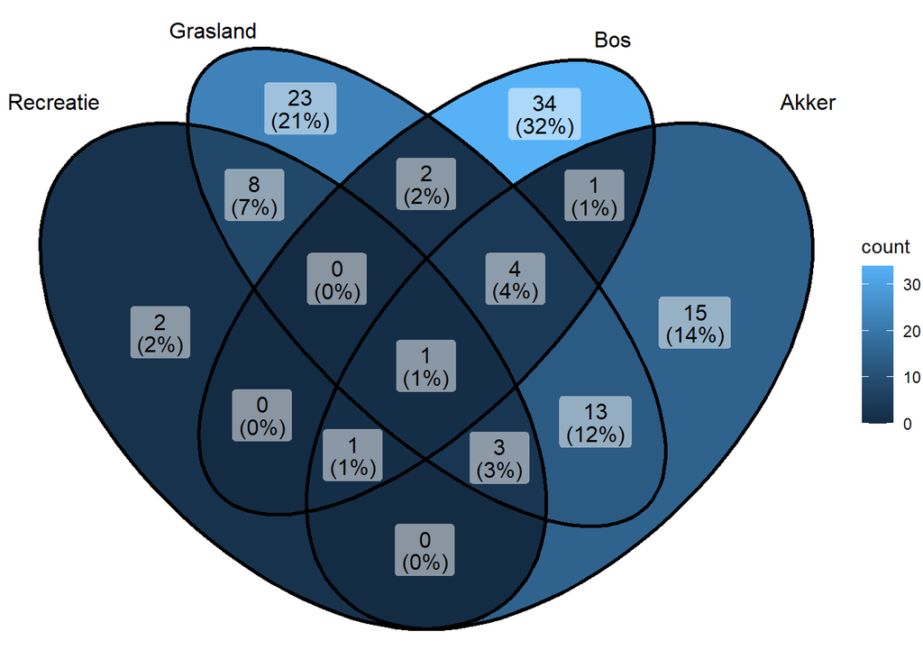

```r
tidy_physeq_insecta %>%
  tidytacos::tacoplot_venn(Landgebruik)
```

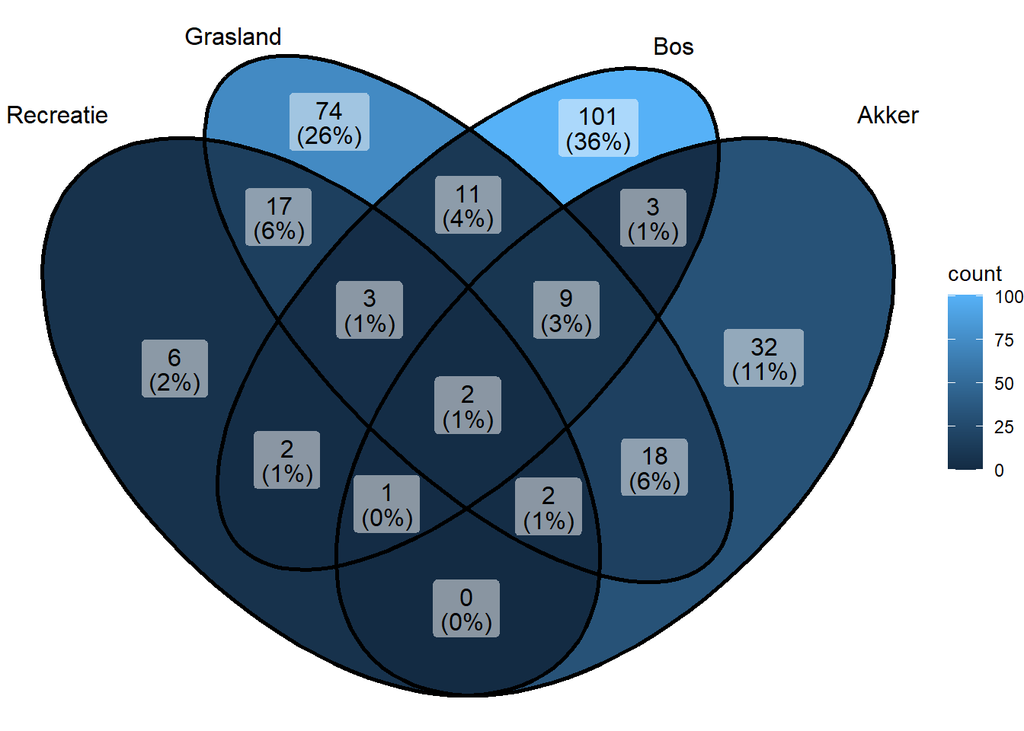

```r
tidy_physeq_rarefied %>%
  tidytacos::tacoplot_venn(Landgebruik)
```

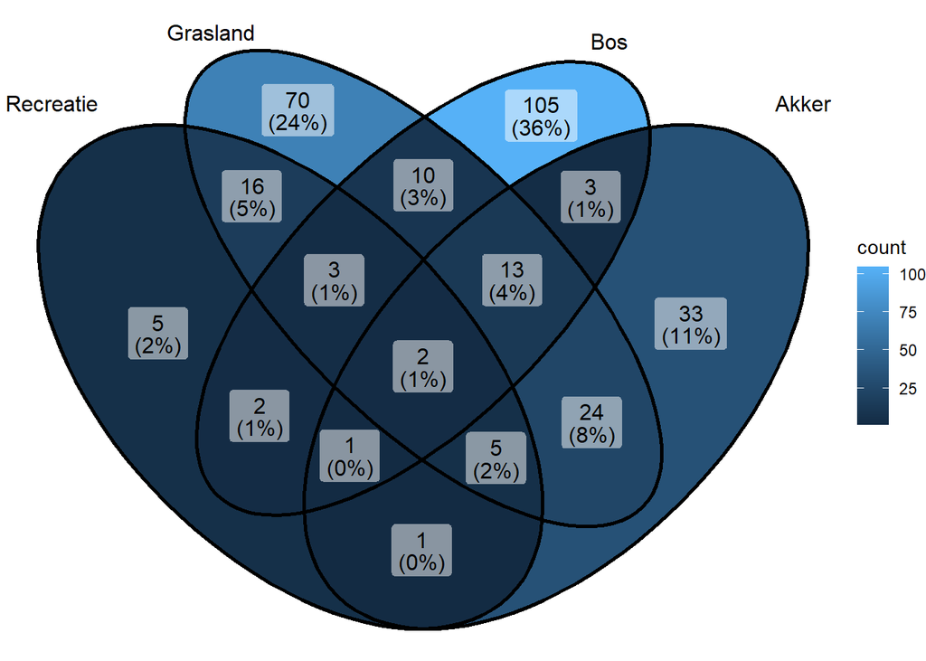

```r
tidy_physeq %>%
  tidytacos::tacoplot_venn(Landgebruik)
```

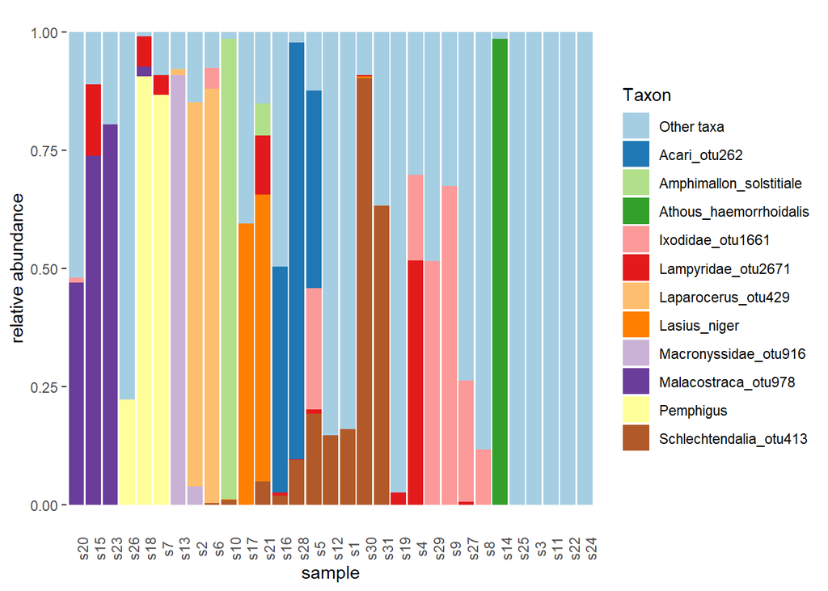

```r
tidy_physeq_insecta %>%
  tidytacos::tacoplot_stack()
```

Hiervoor gebruiken we beter de Krona charts

```r
# integratie Krona werkt nog niet, installatie probleem

# Create a new combined column
combined_column <- paste(sample_data(physeq)$Landgebruik, sample_data(physeq)$Protocol2, sep = "_")

# Add the new combined column to the sample metadata with the desired name
sample_data(physeq)$Landgebruik_Protocol2 <- combined_column

# Update the phyloseq object with the modified sample data
physeq <- merge_phyloseq(physeq, sample_data(physeq))


if (system(command = "which ktImportText",  intern = FALSE, ignore.stderr = TRUE,  ignore.stdout = TRUE) != 1) {
  psadd::plot_krona(physeq, "ejp_Olig01_insecta_rar_species_alle_stalen_Landgebruik_per_Protocol2", "Landgebruik_Protocol2", trim = T)
}
```

onderstaande bar plots nog aan te passen

```r
# werkt nog niet

tidy_physeq %>%
  tidytacos::tacoplot_stack(x = Landgebruik)
```

```r
# werkt nog niet

tidy_physeq %>%
  tidytacos::tacoplot_stack(x = Protocol2)
```

## 3.5 Alfa-diversiteit

### 3.5.1 Regressiemodel met correctie voor totaal aantal reads

Het geobserveerde aantal taxa neemt toe met het aantal reads in een staal:

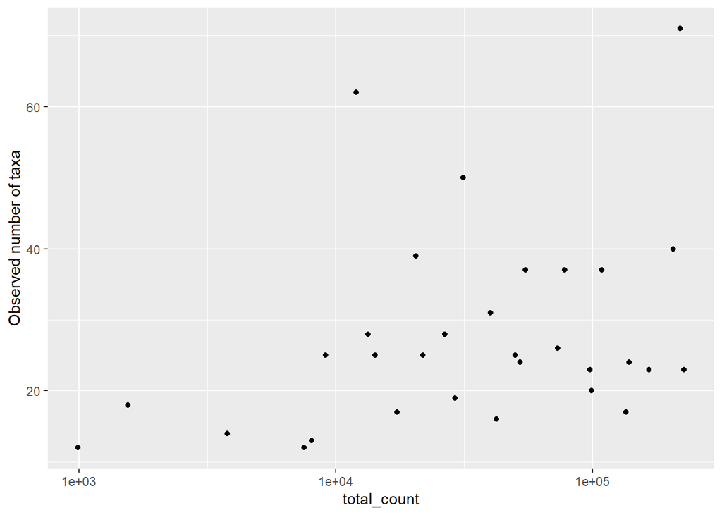

```r
tidy_physeq$samples %>%
  filter(total_count > 0) %>%
  ggplot(
    aes(x = total_count, y = observed)) +
  geom_point() +
  scale_x_log10() +
  labs(y = "Observed number of taxa")
```

We fitten een model waarbij we de log van het totaal aantal reads in een staal als covariaat toevoegen samen met landgebruik en Protocol2 van het staal (de laatste twee in interactie). We voegen ook een random intercept toe die aangeeft op welke locatie een staal werd genomen. Hiermee geven we aan dat stalen op verschillende Protocol2, maar dezelfde locatie, gecorreleerd zijn. Voor deze analyse, verwijderen we enkele stalen met een laag totaal aantal reads ($\leq 1e+4$).

We modelleren de soortenrijkdom als een Negatief Binomiaal model omdat we verwachten dat deze data overdispersie vertonen ten opzichte van een Poisson verdeling (waar de veronderstelling is dat de variantie gelijk aan het gemiddelde).

```r
samples_totcount_10k <- tidy_physeq$samples %>%
  filter(total_count > 1e+4)

form_insecta_richness <- formula(
  observed ~
    log(total_count)
  + Landgebruik
  + Protocol2
  + Landgebruik:Protocol2
  + (1 | Locatie)
  )

m_insecta_richness <- glmmTMB::glmmTMB(
  formula = form_insecta_richness,
  data = samples_totcount_10k,
  family = glmmTMB::nbinom2())
```

```r
performance::check_model(m_insecta_richness)
```

[output not shown]

```r
summary(m_insecta_richness)
```

[output not shown]

```r
car::Anova(m_insecta_richness)
```

[output not shown]

```r
marginaleffects::plot_predictions(
  m_insecta_richness,
  condition = c("total_count"),
  vcov = vcov(m_insecta_richness)) +
  labs(y = "Voorspeld aantal taxa") +
  scale_x_log10()
```

[output not shown]

We kunnen nu predicties maken van soortenrijkdom waarbij we controleren voor het totaal aantal reads in een staal:

```r
marginaleffects::plot_predictions(
  m_insecta_richness,
  condition = c("Landgebruik", "Protocol2"),
  vcov = vcov(m_insecta_richness),
  re.form = NA,
  type = "response") +
  labs(y = "Voorspelde aantal taxa")
```

[output not shown]

### 3.5.2 Rarefaction analyse

Dit is een alternatief voor voorgaande analyse. Schatting van de soortenrijkdom via rarefaction analyse.

```r
sam_new <- data.frame(sample_data(physeq_full))


estimated_species_richness <- vegan::rarefy(
  veganobject_physeq_full,
  12057,
  se = TRUE,
  MARGIN = 1)
true_rarefaction_results <- cbind(
  sam_new %>% select(Naam, Protocol2, Landgebruik),
  est = estimated_species_richness["S", ],
  se = estimated_species_richness["se", ]) %>%
  as_tibble() %>%
  mutate(est_lower = est - 2 * se,
         est_upper = est + 2 * se)
```

```r
glimpse(true_rarefaction_results)
```

```
## Rows: 31
## Columns: 7
## $ Naam        <chr> "Molenbeek_0_10", "Herentals_0_10", "Diepenbeek_0_10", "Bu…
## $ Protocol2   <chr> "INBO_0_10", "INBO_0_10", "INBO_0_10", "INBO_0_10", "INBO_…
## $ Landgebruik <chr> "Recreatie", "Grasland", "Bos", "Akker", "Grasland", "Gras…
## $ est         <dbl> 24.68265, 34.73556, 60.81006, 18.00000, 35.81588, 37.76387…
## $ se          <dbl> 1.3156477, 1.0342988, 1.6980979, 0.0000000, 0.7224802, 0.9…
## $ est_lower   <dbl> 22.05135, 32.66696, 57.41387, 18.00000, 34.37092, 35.93310…
## $ est_upper   <dbl> 27.31395, 36.80416, 64.20626, 18.00000, 37.26084, 39.59464…
```

```r
# verwijder gevallen waar se te klein is of nul is
true_rarefaction_results <- true_rarefaction_results %>%
  filter(se > 0.1)
```

```r
library(brms)
form_rarefaction <- bf(
  est | se(se, sigma = TRUE) ~
  + Landgebruik
  + Protocol2
  + Landgebruik:Protocol2
  + (1 | Naam)
)

m_rarefaction <- brm(
  formula = form_rarefaction,
  data = true_rarefaction_results,
  family = gaussian())
summary(m_rarefaction)
```

```
##  Family: gaussian
##   Links: mu = identity; sigma = identity
## Formula: est | se(se, sigma = TRUE) ~ +Landgebruik + Protocol2 + Landgebruik:Protocol2 + (1 | Naam)
##    Data: true_rarefaction_results (Number of observations: 24)
##   Draws: 4 chains, each with iter = 2000; warmup = 1000; thin = 1;
##          total post-warmup draws = 4000
##
## Group-Level Effects:
## ~Naam (Number of levels: 24)
##               Estimate Est.Error l-95% CI u-95% CI Rhat Bulk_ESS Tail_ESS
## sd(Intercept)     4.32      2.49     0.25     9.11 1.01      354     1245
##
## Population-Level Effects:
##                                          Estimate Est.Error l-95% CI u-95% CI
## Intercept                                   18.81      7.94     2.75    34.17
## LandgebruikBos                              41.70     11.16    19.92    64.47
## LandgebruikGrasland                         12.35      8.88    -5.33    29.90
## LandgebruikRecreatie                         5.95     11.27   -15.62    28.58
## Protocol2INBO_10_30                          3.52      8.85   -13.49    21.09
## Protocol2Lucas                              -3.08     11.27   -24.47    18.49
## LandgebruikBos:Protocol2INBO_10_30         -41.05     13.24   -67.75   -15.45
## LandgebruikGrasland:Protocol2INBO_10_30     -9.40     10.47   -29.99    10.55
## LandgebruikRecreatie:Protocol2INBO_10_30   -12.26     14.35   -39.49    17.80
## LandgebruikBos:Protocol2Lucas              -17.72     14.80   -48.28    11.16
## LandgebruikGrasland:Protocol2Lucas          -3.04     13.43   -29.45    23.75
## LandgebruikRecreatie:Protocol2Lucas         -5.50     15.85   -37.47    25.01
##                                          Rhat Bulk_ESS Tail_ESS
## Intercept                                1.00      741     1211
## LandgebruikBos                           1.00      961     1283
## LandgebruikGrasland                      1.00      783     1224
## LandgebruikRecreatie                     1.00      868     1055
## Protocol2INBO_10_30                      1.00      712     1178
## Protocol2Lucas                           1.00      667      862
## LandgebruikBos:Protocol2INBO_10_30       1.00      951      965
## LandgebruikGrasland:Protocol2INBO_10_30  1.00      815     1313
## LandgebruikRecreatie:Protocol2INBO_10_30 1.00      906      994
## LandgebruikBos:Protocol2Lucas            1.00      854     1227
## LandgebruikGrasland:Protocol2Lucas       1.00      816     1579
## LandgebruikRecreatie:Protocol2Lucas      1.00      713      442
##
## Family Specific Parameters:
##       Estimate Est.Error l-95% CI u-95% CI Rhat Bulk_ESS Tail_ESS
## sigma     5.75      2.31     1.78    10.67 1.02      235      241
##
## Draws were sampled using sampling(NUTS). For each parameter, Bulk_ESS
## and Tail_ESS are effective sample size measures, and Rhat is the potential
## scale reduction factor on split chains (at convergence, Rhat = 1).
```

Dit model geeft gelijkaardige resultaten als het model waarbij we rechtstreeks werkten met de geobserveerde aantallen taxa en (de log van) het totaal aantal reads als covariaat toevoegden.

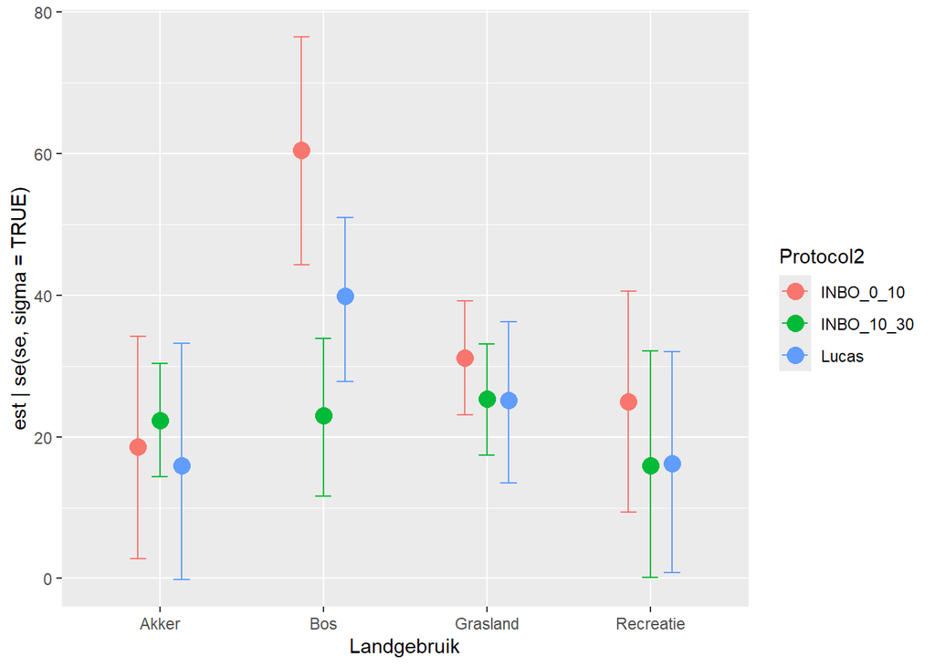

```r
conditional_effects(
  m_rarefaction,
    effects = c("Landgebruik:Protocol2"),
  re.form = NA)
```

## 3.6 OTU counts

per phylum full primerset data

```r
# Count OTUs per Phylum
tax_table(physeq_Inse01) %>%
  as.data.frame() %>%
  as_tibble() %>%
  group_by(phylum) %>%
  summarise(OTU_Count = n()) %>%
  arrange(desc(OTU_Count)) %>%
  kable()
```

| phylum | OTU_Count |
| --- | --- |
| Arthropoda | 293 |
| Annelida | 177 |

per class full primerset data

```r
# Count OTUs per Class
tax_table(physeq_Inse01) %>%
  as.data.frame() %>%
  as_tibble() %>%
  group_by(class) %>%
  summarise(OTU_Count = n()) %>%
  arrange(desc(OTU_Count)) %>%
  kable()
```

| class | OTU_Count |
| --- | --- |
| Clitellata | 177 |
| Collembola | 157 |
| Insecta | 87 |
| Arachnida | 24 |
| Chilopoda | 6 |
| Malacostraca | 4 |
| Arthropoda_otu1245 | 1 |
| Arthropoda_otu1636 | 1 |
| Arthropoda_otu2778 | 1 |
| Arthropoda_otu3482 | 1 |
| Arthropoda_otu3684 | 1 |
| Arthropoda_otu3922 | 1 |
| Arthropoda_otu406 | 1 |
| Arthropoda_otu442 | 1 |
| Arthropoda_otu4552 | 1 |
| Arthropoda_otu464 | 1 |
| Arthropoda_otu4761 | 1 |
| Arthropoda_otu953 | 1 |
| Arthropoda_otu98 | 1 |
| Diplura | 1 |
| Diplura_otu5144 | 1 |

per phylum insecta sl subset

```r
# Count OTUs per Phylum
tax_table(physeq) %>%
  as.data.frame() %>%
  as_tibble() %>%
  group_by(phylum) %>%
  summarise(OTU_Count = n()) %>%
  arrange(desc(OTU_Count)) %>%
  kable()
```

| phylum | OTU_Count |
| --- | --- |
| Arthropoda | 107 |

Dat zijn dus het aantal Arthropoda OTUs gekend tot op klasse niveau (zonder de Collembola)

per class insecta sl subset

```r
# Count OTUs per Class
tax_table(physeq) %>%
  as.data.frame() %>%
  as_tibble() %>%
  group_by(class) %>%
  summarise(OTU_Count = n()) %>%
  arrange(desc(OTU_Count)) %>%
  kable()
```

| class | OTU_Count |
| --- | --- |
| Insecta | 73 |
| Arachnida | 24 |
| Chilopoda | 5 |
| Malacostraca | 4 |
| Diplura | 1 |

per order insecta sl subset

```r
# Count OTUs per order
tax_table(physeq) %>%
  as.data.frame() %>%
  as_tibble() %>%
  group_by(order) %>%
  summarise(OTU_Count = n()) %>%
  arrange(desc(OTU_Count)) %>%
  kable()
```

| order | OTU_Count |
| --- | --- |
| Coleoptera | 31 |
| Diptera | 18 |
| Mesostigmata | 16 |
| Hemiptera | 9 |
| Hymenoptera | 7 |
| Ixodida | 4 |
| Geophilomorpha | 3 |
| Orthoptera | 2 |
| Siphonaptera | 2 |
| Acari | 1 |
| Amphipoda | 1 |
| Arachnida_otu4278 | 1 |
| Araneae | 1 |
| Chilopoda_otu1291 | 1 |
| Diplura | 1 |
| Insecta_otu5045 | 1 |
| Lepidoptera | 1 |
| Malacostraca_otu3194 | 1 |
| Malacostraca_otu4144 | 1 |
| Malacostraca_otu978 | 1 |
| Opiliones | 1 |
| Phthiraptera | 1 |
| Scolopendromorpha | 1 |
| Thysanoptera | 1 |

per order insecta sl subset known orders

```r
# Count OTUs per order
tax_table(physeq_known_order) %>%
  as.data.frame() %>%
  as_tibble() %>%
  group_by(order) %>%
  summarise(OTU_Count = n()) %>%
  arrange(desc(OTU_Count)) %>%
  kable()
```

| order | OTU_Count |
| --- | --- |
| Coleoptera | 31 |
| Diptera | 18 |
| Mesostigmata | 16 |
| Hemiptera | 9 |
| Hymenoptera | 7 |
| Ixodida | 4 |
| Geophilomorpha | 3 |
| Orthoptera | 2 |
| Siphonaptera | 2 |
| Acari | 1 |
| Amphipoda | 1 |
| Araneae | 1 |
| Diplura | 1 |
| Lepidoptera | 1 |
| Opiliones | 1 |
| Phthiraptera | 1 |
| Scolopendromorpha | 1 |
| Thysanoptera | 1 |

per family insecta sl subset

```r
# Count OTUs per family
tax_table(physeq) %>%
  as.data.frame() %>%
  as_tibble() %>%
  group_by(family) %>%
  summarise(OTU_Count = n()) %>%
  arrange(desc(OTU_Count)) %>%
  kable()
```

| family | OTU_Count |
| --- | --- |
| Curculionidae | 7 |
| Elateridae | 5 |
| Macrochelidae | 5 |
| Discourellidae | 4 |
| Ixodidae | 4 |
| Pemphigidae | 4 |
| Sciaridae | 4 |
| Cicadellidae | 3 |
| Hydraenidae | 3 |
| Acrididae | 2 |
| Aphididae | 2 |
| Cantharidae | 2 |
| Cecidomyiidae | 2 |
| Chironomidae | 2 |
| Chrysomelidae | 2 |
| Dolichopodidae | 2 |
| Empididae | 2 |
| Formicidae | 2 |
| Linotaeniidae | 2 |
| Lycidae | 2 |
| Parasitidae | 2 |
| Tenthredinidae | 2 |
| Varroidae | 2 |
| Acari_otu262 | 1 |
| Adelidae | 1 |
| Arachnida_otu4278 | 1 |
| Bibionidae | 1 |
| Braconidae | 1 |
| Brentidae | 1 |
| Campodeidae | 1 |
| Carabidae | 1 |
| Cerylonidae | 1 |
| Chilopoda_otu1291 | 1 |
| Coccinellidae | 1 |
| Coleoptera_otu5293 | 1 |
| Cryptopidae | 1 |
| Digamasellidae | 1 |
| Diptera_otu3896 | 1 |
| Geophilidae | 1 |
| Hybotidae | 1 |
| Hydrophilidae | 1 |
| Hymenoptera_otu2955 | 1 |
| Ichneumonidae | 1 |
| Insecta_otu5045 | 1 |
| Ischnopsyllidae | 1 |
| Lampyridae | 1 |
| Macronyssidae | 1 |
| Malacostraca_otu3194 | 1 |
| Malacostraca_otu4144 | 1 |
| Malacostraca_otu978 | 1 |
| Muscidae | 1 |
| Mycetophilidae | 1 |
| Oxyopidae | 1 |
| Phalangiidae | 1 |
| Phthiraptera_otu4690 | 1 |
| Scarabaeidae | 1 |
| Siphonaptera_otu3208 | 1 |
| Staphylinidae | 1 |
| Talitridae | 1 |
| Tenebrionidae | 1 |
| Thripidae | 1 |
| Tipulidae | 1 |
| Uropodidae | 1 |

per family insecta sl subset known families

```r
# Count OTUs per family
tax_table(physeq_known_family) %>%
  as.data.frame() %>%
  as_tibble() %>%
  group_by(family) %>%
  summarise(OTU_Count = n()) %>%
  arrange(desc(OTU_Count)) %>%
  kable()
```

| family | OTU_Count |
| --- | --- |
| Curculionidae | 7 |
| Elateridae | 5 |
| Macrochelidae | 5 |
| Discourellidae | 4 |
| Ixodidae | 4 |
| Pemphigidae | 4 |
| Sciaridae | 4 |
| Cicadellidae | 3 |
| Hydraenidae | 3 |
| Acrididae | 2 |
| Aphididae | 2 |
| Cantharidae | 2 |
| Cecidomyiidae | 2 |
| Chironomidae | 2 |
| Chrysomelidae | 2 |
| Dolichopodidae | 2 |
| Empididae | 2 |
| Formicidae | 2 |
| Linotaeniidae | 2 |
| Lycidae | 2 |
| Parasitidae | 2 |
| Tenthredinidae | 2 |
| Varroidae | 2 |
| Adelidae | 1 |
| Bibionidae | 1 |
| Braconidae | 1 |
| Brentidae | 1 |
| Campodeidae | 1 |
| Carabidae | 1 |
| Cerylonidae | 1 |
| Coccinellidae | 1 |
| Cryptopidae | 1 |
| Digamasellidae | 1 |
| Geophilidae | 1 |
| Hybotidae | 1 |
| Hydrophilidae | 1 |
| Ichneumonidae | 1 |
| Ischnopsyllidae | 1 |
| Lampyridae | 1 |
| Macronyssidae | 1 |
| Muscidae | 1 |
| Mycetophilidae | 1 |
| Oxyopidae | 1 |
| Phalangiidae | 1 |
| Scarabaeidae | 1 |
| Staphylinidae | 1 |
| Talitridae | 1 |
| Tenebrionidae | 1 |
| Thripidae | 1 |
| Tipulidae | 1 |
| Uropodidae | 1 |

Per genus insecta sl subset

```r
tax_table(physeq) %>%
  as.data.frame() %>%
  group_by(genus) %>%
  summarise(OTU_Count = n()) %>%
  arrange(desc(OTU_Count)) %>%
  kable()
```

| genus | OTU_Count |
| --- | --- |
| Barypeithes | 2 |
| Corynoptera | 2 |
| Macrocheles | 2 |
| Polydrusus | 2 |
| Smittia | 2 |
| Varroa | 2 |
| Acari_otu262 | 1 |
| Acnemia | 1 |
| Acrididae_otu1641 | 1 |
| Adrastus | 1 |
| Agriotes | 1 |
| Amphimallon | 1 |
| Aphididae_otu4359 | 1 |
| Aphrodes | 1 |
| Arachnida_otu4278 | 1 |
| Athous | 1 |
| Baizongia | 1 |
| Braconidae_otu2294 | 1 |
| Bradysia | 1 |
| Campodeidae_otu1231 | 1 |
| Cercyon | 1 |
| Cerylonidae_otu4888 | 1 |
| Chilopoda_otu1291 | 1 |
| Chorthippus | 1 |
| Chrysomelidae_otu1847 | 1 |
| Chrysomelidae_otu4764 | 1 |
| Chrysotimus | 1 |
| Cicadellidae_otu5217 | 1 |
| Coleoptera_otu5293 | 1 |
| Cryptops | 1 |

[output cut: 71 more lines]

Per genus insecta sl subset known genera

```r
tax_table(physeq_known_genera) %>%
  as.data.frame() %>%
  group_by(genus) %>%
  summarise(OTU_Count = n()) %>%
  arrange(desc(OTU_Count)) %>%
  kable()
```

| genus | OTU_Count |
| --- | --- |
| Barypeithes | 2 |
| Corynoptera | 2 |
| Macrocheles | 2 |
| Polydrusus | 2 |
| Smittia | 2 |
| Varroa | 2 |
| Acnemia | 1 |
| Adrastus | 1 |
| Agriotes | 1 |
| Amphimallon | 1 |
| Aphrodes | 1 |
| Athous | 1 |
| Baizongia | 1 |
| Bradysia | 1 |
| Cercyon | 1 |
| Chorthippus | 1 |
| Chrysotimus | 1 |
| Cryptops | 1 |
| Dendrolaelaps | 1 |
| Denticollis | 1 |
| Dilophus | 1 |
| Dolichopus | 1 |
| Eupteryx | 1 |
| Geophilus | 1 |
| Harmonia | 1 |
| Hilara | 1 |
| Laparocerus | 1 |
| Lasius | 1 |
| Lycocerus | 1 |
| Malthodes | 1 |
| Nalassus | 1 |
| Nanophyes | 1 |
| Nematopogon | 1 |
| Nematus | 1 |
| Ochthebius | 1 |
| Otiorhynchus | 1 |
| Parasitus | 1 |
| Pemphigus | 1 |
| Phytosciara | 1 |
| Platypalpus | 1 |
| Polyardis | 1 |
| Rhopalosiphum | 1 |
| Rilaena | 1 |
| Schlechtendalia | 1 |
| Sitodiplosis | 1 |
| Sitona | 1 |
| Stomoxys | 1 |
| Strigamia | 1 |
| Tachyporus | 1 |
| Tipula | 1 |
| Trechus | 1 |

Per species (check of er species zijn met meer dan 1 OTU)

```r
tax_table(physeq) %>%
  as.data.frame() %>%
  group_by(species) %>%
  summarise(OTU_Count = n()) %>%
  filter(OTU_Count > 1) %>%
  arrange(desc(OTU_Count)) %>%
  kable()
```

| species | OTU_Count |
| --- | --- |

Per species known species (check of er species zijn met meer dan 1 OTU)

```r
tax_table(physeq_known_species) %>%
  as.data.frame() %>%
  group_by(species) %>%
  summarise(OTU_Count = n()) %>%
  filter(OTU_Count > 1) %>%
  arrange(desc(OTU_Count)) %>%
  kable()
```

| species | OTU_Count |
| --- | --- |

## 3.7 Read counts

Overzicht van som van reads per phylum:

```r
tidy_physeq_inse01 %>%
  tidytacos::aggregate_taxa(rank = "phylum") %>%
  tidytacos::everything() %>%
  group_by(phylum) %>%
  summarise(read_counts = sum(count)) %>%
  mutate(percentage = round((read_counts / sum(read_counts)) * 100, 1)) %>% # Round to 2 decimal places
  arrange(desc(read_counts)) %>%
  select(phylum, percentage) %>% # Keep only necessary columns if desired
  kable()
```

| phylum | percentage |
| --- | --- |
| Annelida | 65.3 |
| Arthropoda | 34.7 |

Overzicht van som van reads per class:

```r
tidy_physeq_inse01 %>%
  tidytacos::aggregate_taxa(rank = "class") %>%
  tidytacos::everything() %>%
  group_by(class) %>%
  summarise(read_counts = sum(count)) %>%
  mutate(percentage = round((read_counts / sum(read_counts)) * 100, 2)) %>% # Calculate and round percentage
  arrange(desc(read_counts)) %>%
  select(class, percentage) %>% # Keep only necessary columns if desired
  kable()
```

| class | percentage |
| --- | --- |
| Clitellata | 65.26 |
| Collembola | 17.44 |
| Insecta | 9.66 |
| Arachnida | 2.60 |
| Arthropoda_otu98 | 1.48 |
| Arthropoda_otu1636 | 1.04 |
| Arthropoda_otu442 | 0.75 |
| Arthropoda_otu464 | 0.64 |
| Arthropoda_otu406 | 0.63 |
| Malacostraca | 0.30 |
| Arthropoda_otu1245 | 0.09 |
| Arthropoda_otu4552 | 0.03 |
| Chilopoda | 0.02 |
| Arthropoda_otu2778 | 0.02 |
| Arthropoda_otu953 | 0.01 |
| Arthropoda_otu3482 | 0.01 |
| Arthropoda_otu3684 | 0.01 |
| Diplura | 0.01 |
| Arthropoda_otu3922 | 0.01 |
| Arthropoda_otu4761 | 0.00 |
| Diplura_otu5144 | 0.00 |

Overzicht van som van reads per phylum insecta sl subset:

```r
tidy_physeq_insecta %>%
  tidytacos::aggregate_taxa(rank = "phylum") %>%
  tidytacos::everything() %>%
  group_by(phylum) %>%
  summarise(read_counts = sum(count)) %>%
  arrange(desc(read_counts)) %>%
  kable()
```

| phylum | read_counts |
| --- | --- |
| Arthropoda | 727828 |

Overzicht van som van reads per class insecta sl subset:

```r
tidy_physeq_insecta %>%
  tidytacos::aggregate_taxa(rank = "class") %>%
  tidytacos::everything() %>%
  group_by(class) %>%
  summarise(read_counts = sum(count)) %>%
  mutate(percentage = round((read_counts / sum(read_counts)) * 100, 2)) %>% # Calculate and round percentage
  arrange(desc(read_counts)) %>%
  select(class, percentage) %>% # Keep only necessary columns if desired
  kable()
```

| class | percentage |
| --- | --- |
| Insecta | 76.71 |
| Arachnida | 20.69 |
| Malacostraca | 2.40 |
| Chilopoda | 0.16 |
| Diplura | 0.05 |

Overzicht van som van reads per orde:

```r
tidy_physeq_insecta %>%
  tidytacos::aggregate_taxa(rank = "order") %>%
  tidytacos::everything() %>%
  group_by(order) %>%
  summarise(read_counts = sum(count)) %>%
  mutate(percentage = round((read_counts / sum(read_counts)) * 100, 2)) %>% # Calculate and round percentage
  arrange(desc(read_counts)) %>%
  select(order, percentage) %>% # Keep only necessary columns if desired
  kable()
```

| order | percentage |
| --- | --- |
| Coleoptera | 63.59 |
| Acari | 13.11 |
| Hemiptera | 5.82 |
| Hymenoptera | 5.27 |
| Ixodida | 4.05 |
| Mesostigmata | 3.46 |
| Malacostraca_otu978 | 2.25 |
| Diptera | 1.15 |
| Orthoptera | 0.46 |
| Siphonaptera | 0.32 |
| Malacostraca_otu3194 | 0.12 |
| Scolopendromorpha | 0.08 |
| Phthiraptera | 0.06 |
| Arachnida_otu4278 | 0.05 |
| Chilopoda_otu1291 | 0.05 |
| Diplura | 0.05 |
| Geophilomorpha | 0.03 |
| Thysanoptera | 0.02 |
| Lepidoptera | 0.02 |
| Malacostraca_otu4144 | 0.01 |
| Opiliones | 0.01 |
| Amphipoda | 0.01 |
| Insecta_otu5045 | 0.01 |
| Araneae | 0.00 |

Overzicht van som van reads per orde known orders:

```r
tidy_physeq_known_order %>%
  tidytacos::aggregate_taxa(rank = "order") %>%
  tidytacos::everything() %>%
  group_by(order) %>%
  summarise(read_counts = sum(count)) %>%
  mutate(percentage = round((read_counts / sum(read_counts)) * 100, 2)) %>% # Calculate and round percentage
  arrange(desc(read_counts)) %>%
  select(order, percentage) %>% # Keep only necessary columns if desired
  kable()
```

| order | percentage |
| --- | --- |
| Coleoptera | 65.21 |
| Acari | 13.44 |
| Hemiptera | 5.97 |
| Hymenoptera | 5.40 |
| Ixodida | 4.16 |
| Mesostigmata | 3.55 |
| Diptera | 1.18 |
| Orthoptera | 0.47 |
| Siphonaptera | 0.33 |
| Scolopendromorpha | 0.08 |
| Phthiraptera | 0.06 |
| Diplura | 0.05 |
| Geophilomorpha | 0.03 |
| Thysanoptera | 0.02 |
| Lepidoptera | 0.02 |
| Opiliones | 0.01 |
| Amphipoda | 0.01 |
| Araneae | 0.00 |

Overzicht van som van reads per family:

```r
tidy_physeq_insecta %>%
  tidytacos::aggregate_taxa(rank = "family") %>%
  tidytacos::everything() %>%
  group_by(family) %>%
  summarise(read_counts = sum(count)) %>%
  mutate(percentage = round((read_counts / sum(read_counts)) * 100, 2)) %>% # Calculate and round percentage
  arrange(desc(read_counts)) %>%
  select(family, percentage) %>% # Keep only necessary columns if desired
  kable()
```

| family | percentage |
| --- | --- |
| Elateridae | 24.36 |
| Scarabaeidae | 21.85 |
| Acari_otu262 | 13.11 |
| Curculionidae | 10.10 |
| Pemphigidae | 5.77 |
| Ixodidae | 4.05 |
| Tenthredinidae | 3.99 |
| Tenebrionidae | 3.57 |
| Malacostraca_otu978 | 2.25 |
| Macronyssidae | 2.07 |
| Hydraenidae | 1.94 |
| Macrochelidae | 1.07 |
| Formicidae | 0.96 |
| Lampyridae | 0.49 |
| Chrysomelidae | 0.47 |
| Acrididae | 0.46 |
| Braconidae | 0.30 |
| Cantharidae | 0.29 |
| Sciaridae | 0.28 |
| Bibionidae | 0.26 |
| Cecidomyiidae | 0.23 |
| Ischnopsyllidae | 0.23 |
| Carabidae | 0.20 |
| Chironomidae | 0.20 |
| Brentidae | 0.18 |
| Parasitidae | 0.13 |
| Malacostraca_otu3194 | 0.12 |
| Siphonaptera_otu3208 | 0.09 |
| Cryptopidae | 0.08 |
| Mycetophilidae | 0.07 |
| Phthiraptera_otu4690 | 0.06 |
| Digamasellidae | 0.06 |
| Lycidae | 0.06 |
| Discourellidae | 0.05 |
| Arachnida_otu4278 | 0.05 |
| Chilopoda_otu1291 | 0.05 |
| Campodeidae | 0.05 |
| Staphylinidae | 0.05 |
| Varroidae | 0.04 |
| Uropodidae | 0.04 |
| Tipulidae | 0.03 |
| Aphididae | 0.02 |
| Thripidae | 0.02 |
| Empididae | 0.02 |
| Diptera_otu3896 | 0.02 |
| Ichneumonidae | 0.02 |
| Adelidae | 0.02 |
| Cicadellidae | 0.02 |
| Dolichopodidae | 0.02 |
| Linotaeniidae | 0.02 |
| Geophilidae | 0.01 |
| Muscidae | 0.01 |
| Malacostraca_otu4144 | 0.01 |
| Hybotidae | 0.01 |
| Coccinellidae | 0.01 |
| Coleoptera_otu5293 | 0.01 |
| Phalangiidae | 0.01 |
| Cerylonidae | 0.01 |
| Insecta_otu5045 | 0.01 |
| Talitridae | 0.01 |
| Hydrophilidae | 0.01 |
| Hymenoptera_otu2955 | 0.00 |
| Oxyopidae | 0.00 |

Overzicht van som van reads per family known families:

```r
tidy_physeq_known_family %>%
  tidytacos::aggregate_taxa(rank = "family") %>%
  tidytacos::everything() %>%
  group_by(family) %>%
  summarise(read_counts = sum(count)) %>%
  mutate(percentage = round((read_counts / sum(read_counts)) * 100, 2)) %>% # Calculate and round percentage
  arrange(desc(read_counts)) %>%
  select(family, percentage) %>% # Keep only necessary columns if desired
  kable()
```

| family | percentage |
| --- | --- |
| Elateridae | 28.93 |
| Scarabaeidae | 25.95 |
| Curculionidae | 12.00 |
| Pemphigidae | 6.86 |
| Ixodidae | 4.81 |
| Tenthredinidae | 4.73 |
| Tenebrionidae | 4.23 |
| Macronyssidae | 2.46 |
| Hydraenidae | 2.30 |
| Macrochelidae | 1.28 |
| Formicidae | 1.14 |
| Lampyridae | 0.59 |
| Chrysomelidae | 0.56 |
| Acrididae | 0.55 |
| Braconidae | 0.35 |
| Cantharidae | 0.35 |
| Sciaridae | 0.33 |
| Bibionidae | 0.30 |
| Cecidomyiidae | 0.28 |
| Ischnopsyllidae | 0.27 |
| Carabidae | 0.23 |
| Chironomidae | 0.23 |
| Brentidae | 0.21 |
| Parasitidae | 0.15 |
| Cryptopidae | 0.10 |
| Mycetophilidae | 0.09 |
| Digamasellidae | 0.07 |
| Lycidae | 0.07 |
| Discourellidae | 0.06 |
| Campodeidae | 0.06 |
| Staphylinidae | 0.06 |
| Varroidae | 0.05 |
| Uropodidae | 0.04 |
| Tipulidae | 0.03 |
| Aphididae | 0.03 |
| Thripidae | 0.03 |
| Empididae | 0.03 |
| Ichneumonidae | 0.03 |
| Adelidae | 0.02 |
| Cicadellidae | 0.02 |
| Dolichopodidae | 0.02 |
| Linotaeniidae | 0.02 |
| Geophilidae | 0.02 |
| Muscidae | 0.02 |
| Hybotidae | 0.02 |
| Coccinellidae | 0.02 |
| Phalangiidae | 0.01 |
| Cerylonidae | 0.01 |
| Talitridae | 0.01 |
| Hydrophilidae | 0.01 |
| Oxyopidae | 0.00 |

Overzicht van som van reads per genus:

```r
tidy_physeq_insecta %>%
  tidytacos::aggregate_taxa(rank = "genus") %>%
  tidytacos::everything() %>%
  group_by(genus) %>%
  summarise(read_counts = sum(count)) %>%
  mutate(percentage = round((read_counts / sum(read_counts)) * 100, 2)) %>% # Calculate and round percentage
  arrange(desc(read_counts)) %>%
  select(genus, percentage) %>% # Keep only necessary columns if desired
  kable()
```

| genus | percentage |
| --- | --- |
| Amphimallon | 21.85 |
| Athous | 18.13 |
| Acari_otu262 | 13.11 |
| Polydrusus | 5.04 |
| Laparocerus | 4.65 |
| Agriotes | 3.81 |
| Ixodidae_otu1661 | 3.79 |
| Nalassus | 3.57 |
| Nematus | 3.14 |
| Pemphigus | 2.90 |
| Schlechtendalia | 2.75 |
| Malacostraca_otu978 | 2.25 |
| Adrastus | 2.08 |
| Macronyssidae_otu916 | 2.07 |
| Hydraenidae_otu68 | 1.90 |
| Lasius | 0.86 |
| Tenthredinidae_otu2355 | 0.85 |
| Macrocheles | 0.59 |
| Lampyridae_otu2671 | 0.49 |
| Chrysomelidae_otu1847 | 0.46 |
| Acrididae_otu1641 | 0.42 |
| Barypeithes | 0.37 |
| Macrochelidae_otu2436 | 0.36 |
| Denticollis | 0.32 |
| Braconidae_otu2294 | 0.30 |
| Lycocerus | 0.28 |
| Dilophus | 0.26 |
| Ischnopsyllidae_otu2485 | 0.23 |
| Bradysia | 0.21 |
| Ixodidae_otu2663 | 0.21 |

[output cut: 71 more lines]

Overzicht van som van reads per genus known genera:

```r
tidy_physeq_known_genera %>%
  tidytacos::aggregate_taxa(rank = "genus") %>%
  tidytacos::everything() %>%
  group_by(genus) %>%
  summarise(read_counts = sum(count)) %>%
  mutate(percentage = round((read_counts / sum(read_counts)) * 100, 2)) %>% # Calculate and round percentage
  arrange(desc(read_counts)) %>%
  select(genus, percentage) %>% # Keep only necessary columns if desired
  kable()
```

| genus | percentage |
| --- | --- |
| Amphimallon | 30.18 |
| Athous | 25.05 |
| Polydrusus | 6.97 |
| Laparocerus | 6.42 |
| Agriotes | 5.26 |
| Nalassus | 4.93 |
| Nematus | 4.33 |
| Pemphigus | 4.01 |
| Schlechtendalia | 3.79 |
| Adrastus | 2.88 |
| Lasius | 1.19 |
| Macrocheles | 0.81 |
| Barypeithes | 0.51 |
| Denticollis | 0.45 |
| Lycocerus | 0.39 |
| Dilophus | 0.35 |
| Bradysia | 0.29 |
| Trechus | 0.27 |
| Smittia | 0.27 |
| Nanophyes | 0.25 |
| Polyardis | 0.22 |
| Baizongia | 0.16 |
| Cryptops | 0.11 |
| Sitodiplosis | 0.10 |
| Acnemia | 0.10 |
| Dendrolaelaps | 0.08 |
| Corynoptera | 0.08 |
| Tachyporus | 0.06 |
| Varroa | 0.06 |
| Chorthippus | 0.05 |
| Ochthebius | 0.04 |
| Tipula | 0.04 |
| Sitona | 0.03 |
| Otiorhynchus | 0.03 |
| Nematopogon | 0.03 |
| Geophilus | 0.02 |
| Stomoxys | 0.02 |
| Platypalpus | 0.02 |
| Harmonia | 0.02 |
| Phytosciara | 0.02 |
| Rilaena | 0.01 |
| Chrysotimus | 0.01 |
| Rhopalosiphum | 0.01 |
| Aphrodes | 0.01 |
| Eupteryx | 0.01 |
| Strigamia | 0.01 |
| Malthodes | 0.01 |
| Dolichopus | 0.01 |
| Cercyon | 0.01 |
| Parasitus | 0.01 |
| Hilara | 0.00 |

Overzicht van som van reads per species:

```r
tidy_physeq_insecta %>%
  tidytacos::aggregate_taxa(rank = "species") %>%
  tidytacos::everything() %>%
  group_by(species) %>%
  summarise(read_counts = sum(count)) %>%
  mutate(percentage = round((read_counts / sum(read_counts)) * 100, 2)) %>% # Calculate and round percentage
  arrange(desc(read_counts)) %>%
  select(species, percentage) %>% # Keep only necessary columns if desired
  kable()
```

| species | percentage |
| --- | --- |
| Amphimallon_solstitiale | 21.85 |
| Athous_haemorrhoidalis | 18.13 |
| Acari_otu262 | 13.11 |
| Polydrusus_cervinus | 5.03 |
| Laparocerus_otu429 | 4.65 |
| Agriotes_lineatus | 3.81 |
| Ixodidae_otu1661 | 3.79 |
| Nalassus_laevioctostriatus | 3.57 |
| Nematus_otu571 | 3.14 |
| Pemphigus | 2.90 |
| Schlechtendalia_otu413 | 2.75 |
| Malacostraca_otu978 | 2.25 |
| Adrastus_rachifer | 2.08 |
| Macronyssidae_otu916 | 2.07 |
| Hydraenidae_otu68 | 1.90 |
| Lasius_niger | 0.86 |
| Tenthredinidae_otu2355 | 0.85 |
| Macrocheles_otu3490 | 0.55 |
| Lampyridae_otu2671 | 0.49 |
| Chrysomelidae_otu1847 | 0.46 |
| Acrididae_otu1641 | 0.42 |
| Macrochelidae_otu2436 | 0.36 |
| Denticollis_linearis | 0.32 |
| Braconidae_otu2294 | 0.30 |
| Lycocerus_otu1946 | 0.28 |
| Dilophus_febrilis | 0.26 |
| Ischnopsyllidae_otu2485 | 0.23 |
| Barypeithes_otu2210 | 0.21 |
| Bradysia_otu3387 | 0.21 |
| Ixodidae_otu2663 | 0.21 |

[output cut: 77 more lines]

Overzicht van som van reads per species known species:

```r
tidy_physeq_known_species %>%
  tidytacos::aggregate_taxa(rank = "species") %>%
  tidytacos::everything() %>%
  group_by(species) %>%
  summarise(read_counts = sum(count)) %>%
  mutate(percentage = round((read_counts / sum(read_counts)) * 100, 2)) %>% # Calculate and round percentage
  arrange(desc(read_counts)) %>%
  select(species, percentage) %>% # Keep only necessary columns if desired
  kable()
```

| species | percentage |
| --- | --- |
| Amphimallon_solstitiale | 36.62 |
| Athous_haemorrhoidalis | 30.39 |
| Polydrusus_cervinus | 8.43 |
| Agriotes_lineatus | 6.39 |
| Nalassus_laevioctostriatus | 5.98 |
| Pemphigus | 4.86 |
| Adrastus_rachifer | 3.49 |
| Lasius_niger | 1.44 |
| Denticollis_linearis | 0.54 |
| Dilophus_febrilis | 0.43 |
| Trechus_quadristriatus | 0.33 |
| Barypeithes_araneiformis | 0.26 |
| Baizongia_pistaciae | 0.19 |
| Cryptops_parisi | 0.14 |
| Tachyporus_nitidulus | 0.08 |
| Chorthippus_parallelus_parallelus | 0.06 |
| Corynoptera_perpusilla | 0.06 |
| Tipula_varipennis | 0.05 |
| Sitona_obsoletus | 0.04 |
| Otiorhynchus_ovatus | 0.04 |
| Nematopogon_swammerdamellus | 0.03 |
| Geophilus_electricus | 0.02 |
| Stomoxys_calcitrans | 0.02 |
| Harmonia_axyridis | 0.02 |
| Rilaena_triangularis | 0.02 |
| Chrysotimus_flaviventris | 0.01 |
| Rhopalosiphum_padi | 0.01 |
| Aphrodes_bicincta | 0.01 |
| Eupteryx_gracilirama | 0.01 |
| Dolichopus_griseipennis | 0.01 |
| Hilara_maura | 0.00 |

## 3.8 Ordinatie

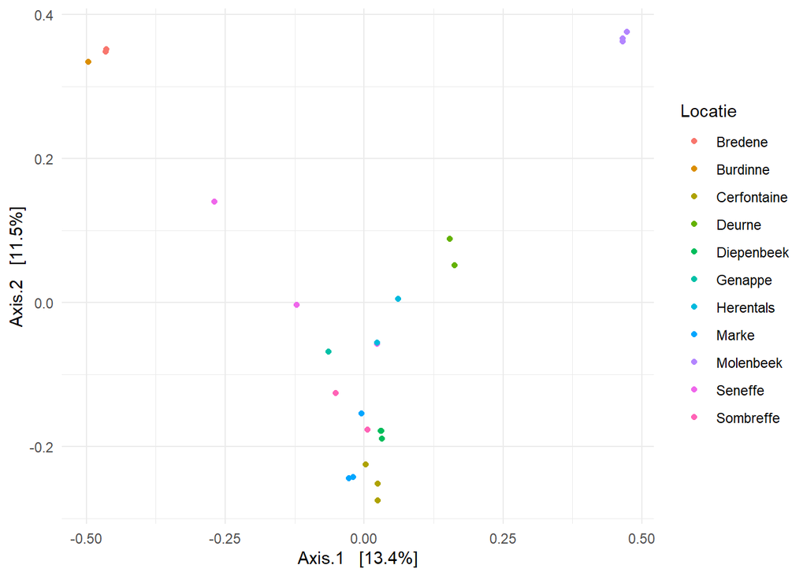

```r
# Perform PCoA
pcoa_result <- ordinate(physeq_full_rarefied, method = "PCoA", distance = "bray")

# Create the ordination plot with color based on land_use and shape
# based on Protocol2
plot_ordination(physeq_full_rarefied, pcoa_result, type = "samples",
                color = "Locatie") +
  theme_minimal()
```

```r
# Hier is duidelijk iets fout gegaan, komt niet overeen met ordinatie plots uit shiny phyloseq

# Perform CLR transformation
clr_physeq_rarefied <- microbiome::transform(physeq_full_rarefied, "clr")

# Calculate Bray distance matrix based on the CLR-transformed data
bray_distance <- phyloseq::distance(clr_physeq_rarefied, method = "bray")

# Perform PCoA
pcoa_result <- ordinate(clr_physeq_rarefied, method = "PCoA", distance = "bray")

# Create the ordination plot with color based on land_use and shape
# based on Protocol2
plot_ordination(clr_physeq_rarefied, pcoa_result, type = "samples",
                color = "Locatie") +
  theme_minimal()
```